# Homework 3 Group I

Elham Babaei, SICKLINGER MARCO, TINTO BEATRICE, ZINNA ISACCO

29/12/2020

# Exercises from *Data Analysis and Graphics Using R*

## Exercise 8 from chapter 6

**Apply the `lm.ridge()` function to the litters data, using the generalized cross-validation (GCV) criterion to choose the tuning parameter. (GCV is an approximation to cross-validation.)**  
- **In particular, estimate the coefficients of the model relating `brainwt` to `bodywt` and `lsize` and compare with the results obtained using `lm()`.**

```r
library(DAAG)
library(MASS)
litters
```

```
##    lsize bodywt brainwt
## 1      3  9.447   0.444
## 2      3  9.780   0.436
## 3      4  9.155   0.417
## 4      4  9.613   0.429
## 5      5  8.850   0.425
## 6      5  9.610   0.434
## 7      6  8.298   0.404
## 8      6  8.543   0.439
## 9      7  7.400   0.409
## 10     7  8.335   0.429
## 11     8  7.040   0.414
## 12     8  7.253   0.409
## 13     9  6.600   0.387
## 14     9  7.260   0.433
## 15    10  6.305   0.410
## 16    10  6.655   0.405
## 17    11  7.183   0.435
## 18    11  6.133   0.407
## 19    12  5.450   0.368
## 20    12  6.050   0.401
```

```r
#GCV
select(lm.ridge(brainwt~., data= litters, lambda = seq(0,10,0.001)))
```

```
## modified HKB estimator is 0
## modified L-W estimator is 0
## smallest value of GCV  at 0.118
```

The optimized value of the parameter $\lambda$ is $0.118$. Then we apply *ridge regression*:

```r
#ridge regression with optimized value of lambda
litters_ridge <- lm.ridge(brainwt~., data=litters, lambda = 0.118)
litters_ridge
```

```
##                   lsize      bodywt
## 0.203442601 0.005661579 0.022050278
```

```r
# linear regression
litters_lm <- lm(brainwt~., data=litters)
litters_lm
```

```
##
## Call:
## lm(formula = brainwt ~ ., data = litters)
##
## Coefficients:
## (Intercept)        lsize       bodywt
##     0.17825      0.00669      0.02431
```

In the ridge regression the coefficients of both `bodywt` and `lsize` are shrinked in favor of the intercept.

- **Using both ridge and ordinary regression, estimate the mean brain weight when litter size is 10 and body weight is 7. Use the bootstrap, with case-resampling, to compute approximate 95% percentile confidence intervals using each method. Compare with the interval obtained using `predict.lm()`.**

```r
#95% Confidence Interval (CI) using bootstrap- lm model
bootsrap_lm <- function(formula, data, B){
  n <- nrow(data)
  s_vect <- rep(0, B)
  for(i in 1:B) {
    ind <- sample(1:n, n, replace = TRUE)
    lm.b<-lm(formula, data=data[ind,])
    s_vect[i] <- coef(lm.b)[1] + coef(lm.b)[2]*10 + coef(lm.b)[3]*7
  }
  CI <- quantile(s_vect, prob=c(0.025, 0.975))
  return(CI)
}
#95% Confidence Interval (CI) using bootstrap- ridge model
bootsrap_ridge <- function(formula, data, B, lambda){
  n <- nrow(data)
  s_vect <- rep(0, B)
  for(i in 1:B) {
    ind <- sample(1:n, n, replace = TRUE)
    ridge.b<-lm.ridge(formula, data=data[ind,], lambda=lambda)
    s_vect[i] <- coef(ridge.b)[1] + coef(ridge.b)[2]*10 + coef(ridge.b)[3]*7
  }
  CI <- quantile(s_vect, prob=c(0.025, 0.975))
  return(CI)
}
```

```r
bootsrap_lm (formula=brainwt~., data=litters, B = 1000)
```

```
##      2.5%     97.5%
## 0.4052386 0.4226844
```

```r
bootsrap_ridge (formula=brainwt~., data=litters, B = 1000, lambda = 0.118)
```

```
##      2.5%     97.5%
## 0.4046865 0.4217762
```

```r
# 95% CI using predict.lm
fixedvalues <- data.frame(lsize=10, bodywt=7)
predict.lm(litters_lm, fixedvalues, interval = "confidence")
```

```
##         fit       lwr       upr
## 1 0.4152947 0.4062582 0.4243312
```

```r
#coverage <- predict(litters_lm, interval="confidence")
#freq_coverage <- mean(litters$brainwt >= coverage[,2] & litters$brainwt <= coverage[,3])
#coverage
#freq_coverage
```

We can see that the bootstrap confidence intervals are quite similar for both models. They are also similar to the confidence interval obtained by using the `predict.lm` built-in function.

## Exercise 10 from chapter 6

- **Construct a scatterplot of `y` (mpg) versus `x1` (displacement). Is the relationship between these variables non-linear?**

```r
library(MPV)
table.b3
```

```
##        y    x1  x2  x3   x4   x5 x6 x7    x8   x9  x10 x11
## 1  18.90 350.0 165 260 8.00 2.56  4  3 200.3 69.9 3910   1
## 2  17.00 350.0 170 275 8.50 2.56  4  3 199.6 72.9 3860   1
## 3  20.00 250.0 105 185 8.25 2.73  1  3 196.7 72.2 3510   1
## 4  18.25 351.0 143 255 8.00 3.00  2  3 199.9 74.0 3890   1
## 5  20.07 225.0  95 170 8.40 2.76  1  3 194.1 71.8 3365   0
## 6  11.20 440.0 215 330 8.20 2.88  4  3 184.5 69.0 4215   1
## 7  22.12 231.0 110 175 8.00 2.56  2  3 179.3 65.4 3020   1
## 8  21.47 262.0 110 200 8.50 2.56  2  3 179.3 65.4 3180   1
## 9  34.70  89.7  70  81 8.20 3.90  2  4 155.7 64.0 1905   0
## 10 30.40  96.9  75  83 9.00 4.30  2  5 165.2 65.0 2320   0
## 11 16.50 350.0 155 250 8.50 3.08  4  3 195.4 74.4 3885   1
## 12 36.50  85.3  80  83 8.50 3.89  2  4 160.6 62.2 2009   0
## 13 21.50 171.0 109 146 8.20 3.22  2  4 170.4 66.9 2655   0
## 14 19.70 258.0 110 195 8.00 3.08  1  3 171.5 77.0 3375   1
```

[output cut: 18 more lines]

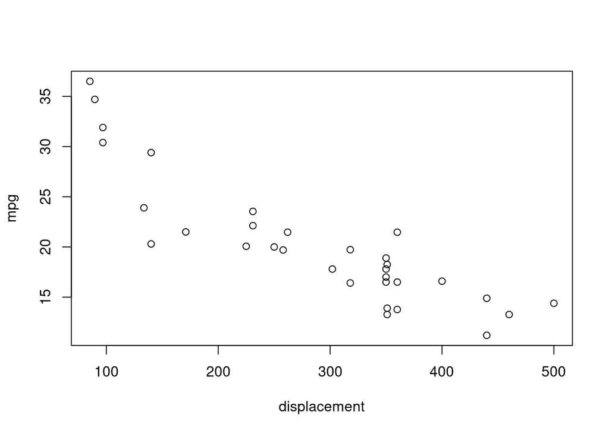

```r
plot(table.b3$x1, table.b3$y, xlab = "displacement", ylab = "mpg")
```

Yes, the relationship between `mpg` and `displacement` seems to be nonlinear.

- **Use the `xyplot()` function, and `x11` (type of transmission) as a `group` variable. Is a linear model reasonable for these data?**

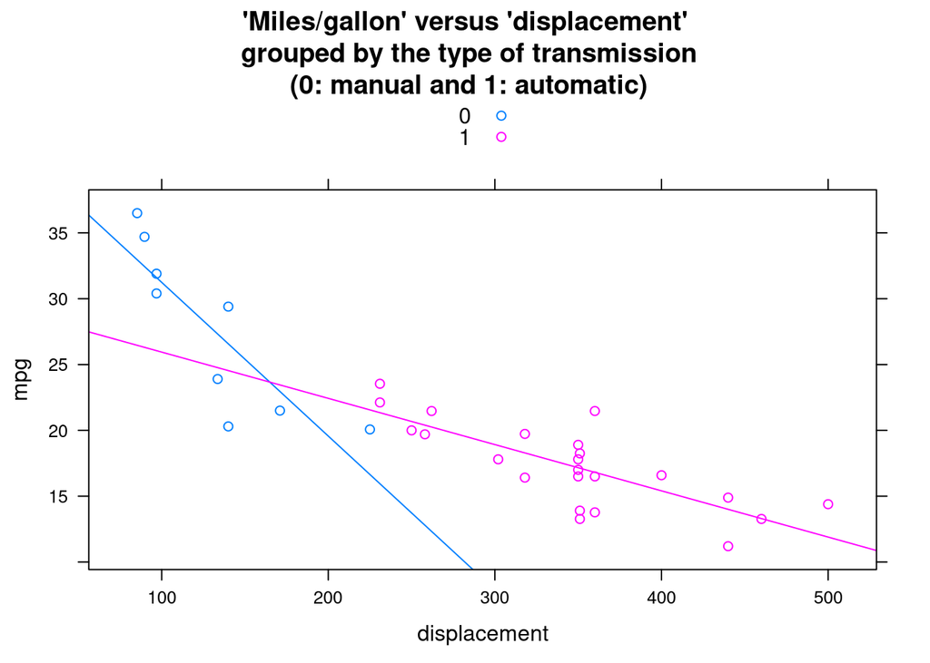

```r
xyplot(y ~ x1, groups = x11, auto.key = TRUE, data = table.b3,  type = c("p", "r"), xlab = "displacement", ylab = "mpg", main = "'Miles/gallon' versus 'displacement'\n grouped by the type of transmission\n (0: manual and 1: automatic)")
```

The graph shows that for each group a linear model seems reasonable. However, it is nonlinear when the types of transmission is not distinguished.

- **Fit the model relating `y` to `x1` and `x11` which gives two lines having possibly different slopes and intercepts. Check the diagnostics. Are there any influential observations? Are there any influential outliers?**

```r
model <- lm(y ~ x1 * x11, data = table.b3)
summary(model)
```

```
##
## Call:
## lm(formula = y ~ x1 * x11, data = table.b3)
##
## Residuals:
##     Min      1Q  Median      3Q     Max
## -6.2712 -1.2660  0.1342  1.5181  4.6599
##
## Coefficients:
##              Estimate Std. Error t value Pr(>|t|)
## (Intercept)  42.91963    2.73493  15.693 2.10e-15 ***
## x1           -0.11677    0.01984  -5.886 2.49e-06 ***
## x11         -13.46371    3.84413  -3.502 0.001567 **
## x1:x11        0.08165    0.02127   3.839 0.000647 ***
## ---
## Signif. codes:  0 '***' 0.001 '**' 0.01 '*' 0.05 '.' 0.1 ' ' 1
##
## Residual standard error: 2.566 on 28 degrees of freedom
## Multiple R-squared:  0.851,  Adjusted R-squared:  0.8351
## F-statistic: 53.33 on 3 and 28 DF,  p-value: 1.064e-11
```

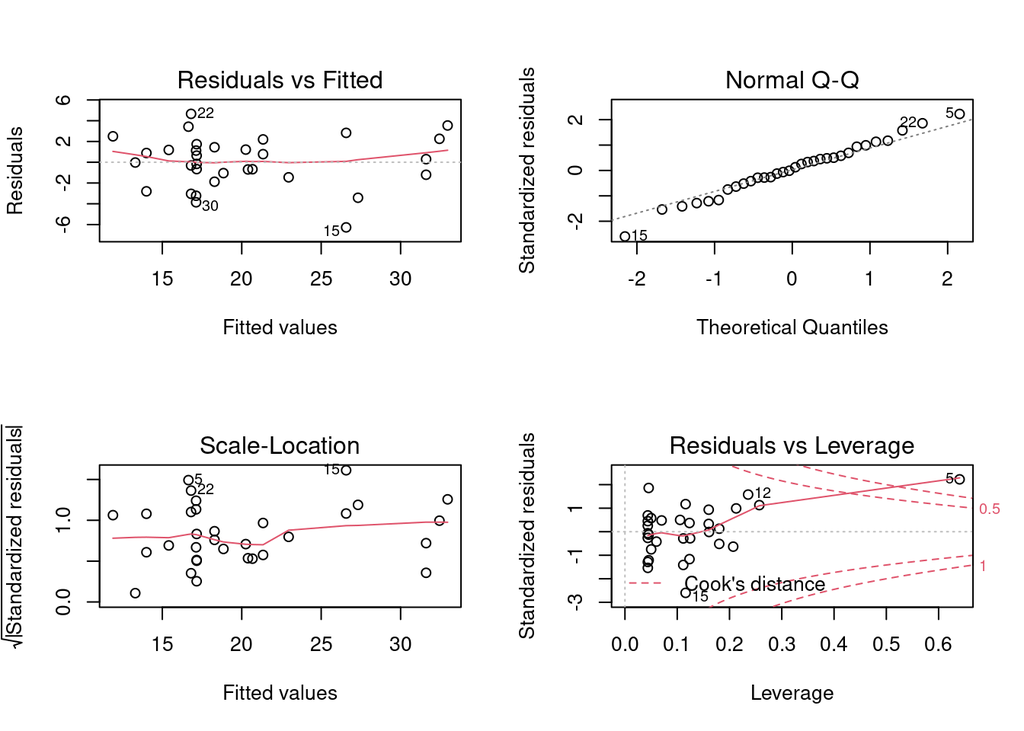

```r
par(mfrow=c(2,2))
plot(model)
```

The *Residual vs Leverage* plot shows that observation 5 is an influential observation as it is located outside of the `Cook's Distance` line. But other plots don’t show strong evidence that it is an outlier.

- **(d) Plot the residuals against the variable `x7` (number of transmission speeds), again using `x11` as a `group` variable. Is there anything striking about this plot?**

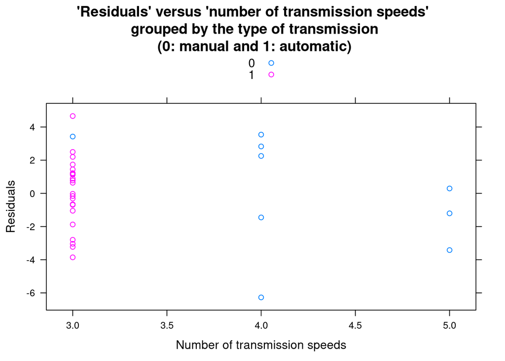

```r
#Plot residuals against x7
xyplot(model$residuals ~ x7, groups = x11, data=table.b3, auto.key=TRUE , xlab = "Number of transmission speeds",ylab = "Residuals", main = "'Residuals' versus 'number of transmission speeds'\n grouped by the type of transmission\n (0: manual and 1: automatic)")
```

It is clear that the two groups are almost perfectly separated except one blue point which is included among pink points.By looking at the dataset, we find out that this point corresponds to observation 5 which is the only car with the number of transmission speeds equal to 3 ($X7=3$) and manual transmission ($X11=0$).

## Exercise 5 from chapter 7

**The data frame cuckoos holds data on the lengths and breadths of eggs of cuckoos, found in the nests of six different species of host birds.**

```r
library(DAAG)
summary(cuckoos)
```

```
##      length         breadth               species         id
##  Min.   :19.60   Min.   :15.00   hedge.sparrow:14   Min.   : 21.00
##  1st Qu.:21.90   1st Qu.:16.20   meadow.pipit :45   1st Qu.: 50.75
##  Median :22.35   Median :16.60   pied.wagtail :15   Median : 81.00
##  Mean   :22.45   Mean   :16.55   robin        :16   Mean   :103.88
##  3rd Qu.:23.23   3rd Qu.:17.00   tree.pipit   :15   3rd Qu.:132.75
##  Max.   :25.00   Max.   :17.50   wren         :15   Max.   :238.00
```

**Fit models for the regression of length on breadth that have:**  
- **a single line for all six species.**

```r
#a single line for all six species
lm.single <- lm(length ~ breadth, data=cuckoos)
summary(lm.single)
```

```
##
## Call:
## lm(formula = length ~ breadth, data = cuckoos)
##
## Residuals:
##      Min       1Q   Median       3Q      Max
## -2.29659 -0.72328 -0.07977  0.70088  2.32696
##
## Coefficients:
##             Estimate Std. Error t value Pr(>|t|)
## (Intercept)    5.341      2.716   1.966   0.0516 .
## breadth        1.034      0.164   6.301 5.28e-09 ***
## ---
## Signif. codes:  0 '***' 0.001 '**' 0.01 '*' 0.05 '.' 0.1 ' ' 1
##
## Residual standard error: 0.9294 on 118 degrees of freedom
## Multiple R-squared:  0.2518, Adjusted R-squared:  0.2454
## F-statistic: 39.71 on 1 and 118 DF,  p-value: 5.276e-09
```

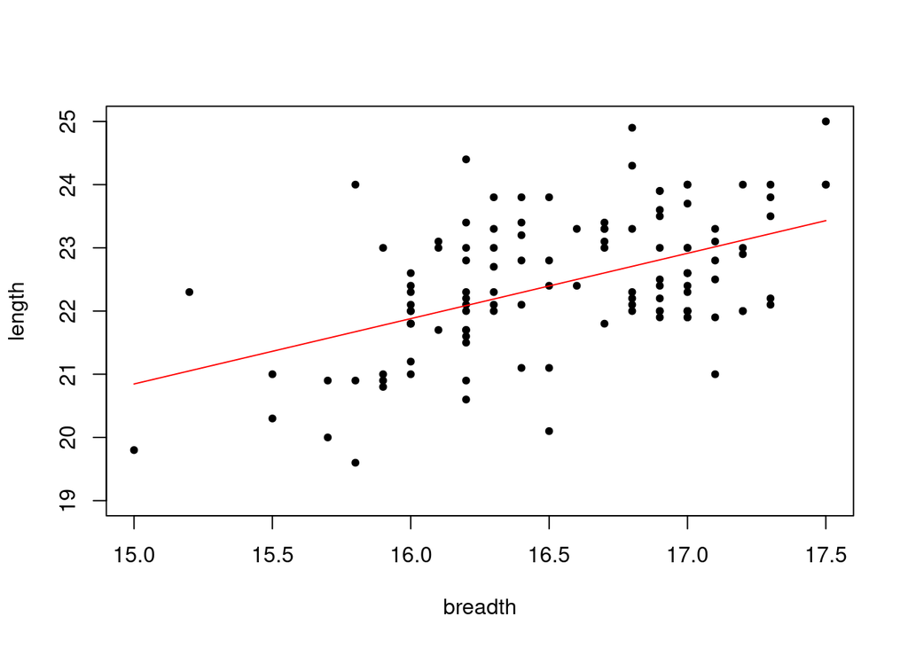

```r
plot(cuckoos$breadth, cuckoos$length, pch = 20, ylim=c(19,25), ylab = "length", xlab = "breadth")
curve(predict(lm.single, data.frame(breadth=x)), add=TRUE, col="red")
```

- **different parallel lines for the different host species.**

```r
#different parallel lines for the different host species
lm.parallel <- lm(length ~ breadth + species, cuckoos)
summary(lm.parallel)
```

```
##
## Call:
## lm(formula = length ~ breadth + species, data = cuckoos)
##
## Residuals:
##      Min       1Q   Median       3Q      Max
## -2.37337 -0.49106 -0.06816  0.52980  2.54470
##
## Coefficients:
##                     Estimate Std. Error t value Pr(>|t|)
## (Intercept)          9.51559    3.01765   3.153 0.002068 **
## breadth              0.81117    0.17951   4.519 1.54e-05 ***
## speciesmeadow.pipit -0.80125    0.25610  -3.129 0.002234 **
## speciespied.wagtail -0.01324    0.31454  -0.042 0.966503
## speciesrobin        -0.30310    0.31137  -0.973 0.332414
## speciestree.pipit    0.04490    0.31143   0.144 0.885621
## specieswren         -1.23912    0.35300  -3.510 0.000644 ***
## ---
## Signif. codes:  0 '***' 0.001 '**' 0.01 '*' 0.05 '.' 0.1 ' ' 1
##
## Residual standard error: 0.8367 on 113 degrees of freedom
## Multiple R-squared:  0.4192, Adjusted R-squared:  0.3884
## F-statistic: 13.59 on 6 and 113 DF,  p-value: 1.439e-11
```

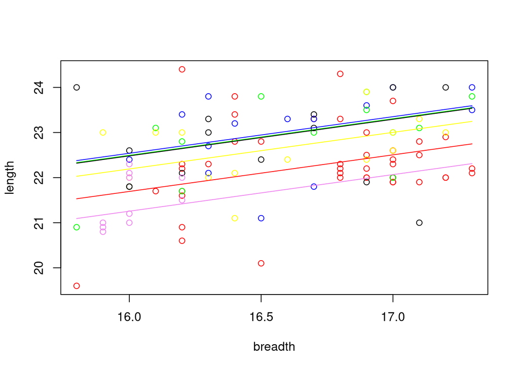

```r
plot(cuckoos$breadth[c(1:45)], cuckoos$length[c(1:45)], col = "red", ylab="length", xlab="breadth")
points(cuckoos$breadth[c(46:60)], cuckoos$length[c(46:60)], col = "blue")
points(cuckoos$breadth[c(61:74)], cuckoos$length[c(61:74)], col = "green")
points(cuckoos$breadth[c(75:90)], cuckoos$length[c(75:90)], col = "yellow")
points(cuckoos$breadth[c(91:105)], cuckoos$length[c(91:105)], col = "black")
points(cuckoos$breadth[c(106:120)], cuckoos$length[c(106:120)], col = "violet")
coefs <- coef(lm.parallel)
curve(coefs[1]+coefs[2]*x+coefs[3],col="red",add=T)
curve(coefs[1]+coefs[2]*x+coefs[6],col="blue",add=T)
curve(coefs[1]+coefs[2]*x,col="green",add=T)
curve(coefs[1]+coefs[2]*x+coefs[5],col="yellow",add=T)
curve(coefs[1]+coefs[2]*x+coefs[4],col="black",add=T)
curve(coefs[1]+coefs[2]*x+coefs[7],col="violet",add=T)
```

- **separate lines for the separate host species.**

```r
#separate lines for the separate host species
lm.separate <- lm(length ~ breadth + species+ breadth:species, cuckoos)
summary(lm.separate)
```

```
##
## Call:
## lm(formula = length ~ breadth + species + breadth:species, data = cuckoos)
##
## Residuals:
##      Min       1Q   Median       3Q      Max
## -2.14805 -0.44416 -0.02604  0.48139  2.41991
##
## Coefficients:
##                             Estimate Std. Error t value Pr(>|t|)
## (Intercept)                  -0.4467     7.2533  -0.062  0.95101
## breadth                       1.4054     0.4325   3.250  0.00154 **
## speciesmeadow.pipit          13.0294     9.0941   1.433  0.15483
## speciespied.wagtail          16.7101    10.9182   1.530  0.12882
## speciesrobin                 15.0521     9.7160   1.549  0.12426
## speciestree.pipit             6.8796    10.9872   0.626  0.53254
## specieswren                  -7.3714    13.3935  -0.550  0.58320
## breadth:speciesmeadow.pipit  -0.8253     0.5425  -1.521  0.13112
## breadth:speciespied.wagtail  -1.0040     0.6569  -1.529  0.12931
## breadth:speciesrobin         -0.9221     0.5842  -1.578  0.11740
## breadth:speciestree.pipit    -0.4066     0.6573  -0.619  0.53749
## breadth:specieswren           0.4222     0.8322   0.507  0.61292
## ---
## Signif. codes:  0 '***' 0.001 '**' 0.01 '*' 0.05 '.' 0.1 ' ' 1
##
## Residual standard error: 0.8332 on 108 degrees of freedom
## Multiple R-squared:  0.4496, Adjusted R-squared:  0.3935
## F-statistic: 8.019 on 11 and 108 DF,  p-value: 4.5e-10
```

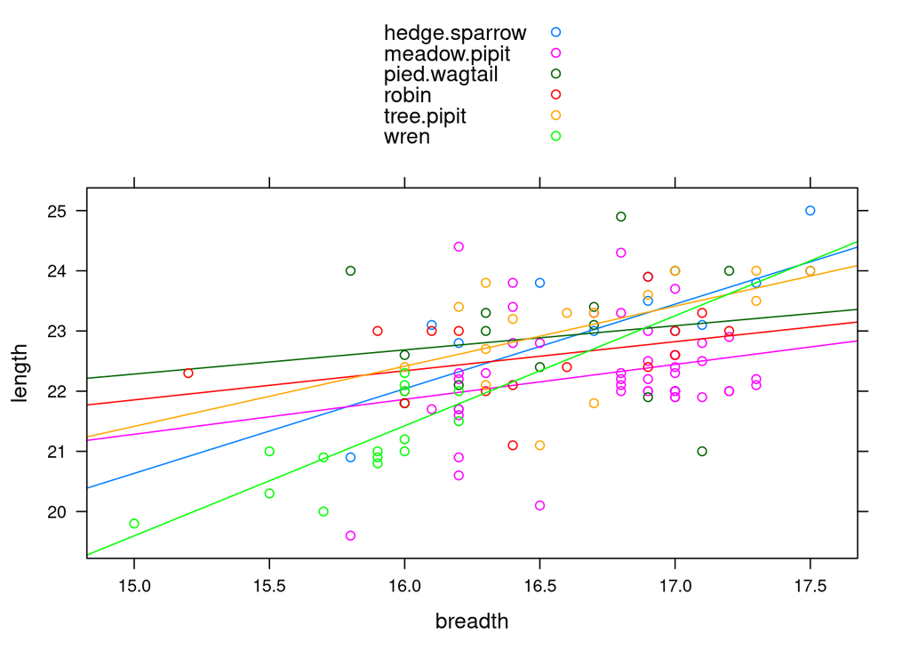

```r
xyplot(length ~ breadth, data = cuckoos, xlab = "breadth", ylab = "length", groups = species, type=c("p","r"), auto.key = TRUE, main = "")
```

**Use the anova() function to print out the sequential analysis of variance table. Which of the three models is preferred? Print out the diagnostic plots for this model. Do they show anything worthy of note? Examine the output coefficients from this model carefully, and decide whether the results seem grouped by host species. How might the results be summarized for reporting purposes?**

```r
#ANOVA
anova(lm.single, lm.parallel, lm.separate)
```

```
## Analysis of Variance Table
##
## Model 1: length ~ breadth
## Model 2: length ~ breadth + species
## Model 3: length ~ breadth + species + breadth:species
##   Res.Df     RSS Df Sum of Sq      F    Pr(>F)
## 1    118 101.923
## 2    113  79.114  5   22.8096 6.5711 2.244e-05 ***
## 3    108  74.978  5    4.1356 1.1914    0.3182
## ---
## Signif. codes:  0 '***' 0.001 '**' 0.01 '*' 0.05 '.' 0.1 ' ' 1
```

The accepted model is the parallel one. Because the reduction in the residual sum of square from model `lm.parallel` to model `lm.separate` in the analysis of variance table has a p-value equal to 0.3182 which is large enough; so there is not enough evidence against the null hypothesis which is parallel model.

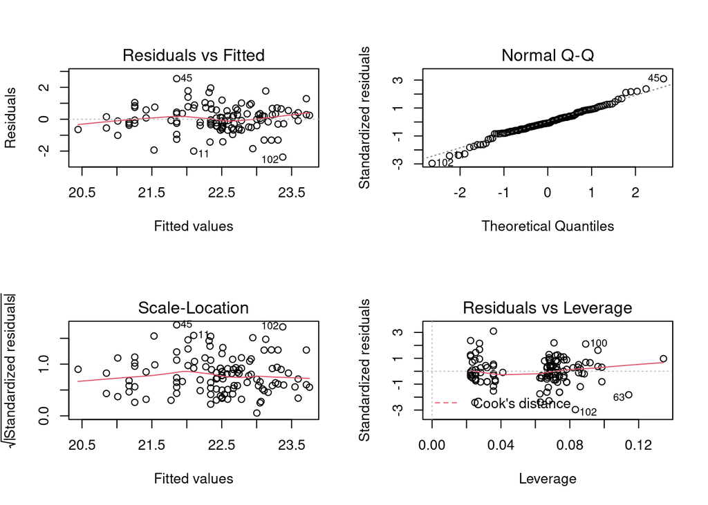

```r
#diagnostic plots for parallel model
par(mfrow=c(2,2))
plot(lm.parallel)
```

The diagnostic plots seem unexceptional. The coefficients of the parallel model show that the species `pied.wagtail`, `robin`, and `tree.pipit` does not have a significant effect on the intercept (due to large p-values). The plot also shows they have very close fitted lines; therefore they can be grouped as one specie along with the other two groups for reporting purposes.

## Exercise 7 from chapter 7

**Apply polynomial regression to the seismic timing data in the data frame geophones. Specifically, check the fits of linear, quadratic, cubic, and quartic (degree = 4) polynomial estimates of the expected thickness as a function of distance. What do you observe about the fitted quartic curve? Do any of the fitted curves capture the curvature of the data in the region where distance is large?**

```r
library(DAAG)
summary(geophones)
```

```
##     distance       thickness
##  Min.   :13.75   Min.   :248.0
##  1st Qu.:30.94   1st Qu.:260.8
##  Median :48.12   Median :274.5
##  Mean   :48.55   Mean   :269.4
##  3rd Qu.:66.56   3rd Qu.:276.0
##  Max.   :83.75   Max.   :283.0
```

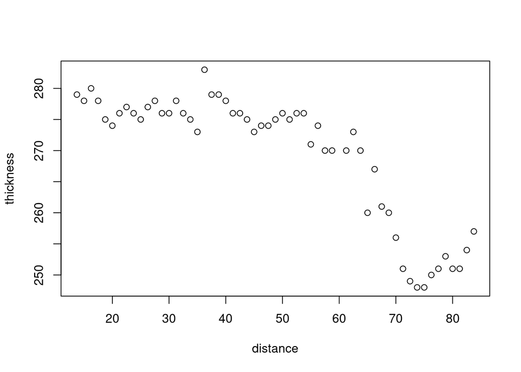

```r
plot(thickness ~ distance, data=geophones)
```

The plot shows that the relationship between thickness and distance is not linear.

```r
#linear
#lm1 <- lm(thickness ~ distance, data=geophones)
lm1 <- lm(thickness ~ poly(distance, 1), data = geophones)
summary(lm1)
```

```
##
## Call:
## lm(formula = thickness ~ poly(distance, 1), data = geophones)
##
## Residuals:
##      Min       1Q   Median       3Q      Max
## -10.7766  -4.3974  -0.5347   4.9021   9.4762
##
## Coefficients:
##                   Estimate Std. Error t value Pr(>|t|)
## (Intercept)       269.4107     0.7489  359.74  < 2e-16 ***
## poly(distance, 1) -65.3414     5.6043  -11.66 2.27e-16 ***
## ---
## Signif. codes:  0 '***' 0.001 '**' 0.01 '*' 0.05 '.' 0.1 ' ' 1
##
## Residual standard error: 5.604 on 54 degrees of freedom
## Multiple R-squared:  0.7157, Adjusted R-squared:  0.7104
## F-statistic: 135.9 on 1 and 54 DF,  p-value: 2.268e-16
```

```r
#quadratic
#lm2 <- lm(thickness ~ distance+I(distance^2), data= geophones)
lm2 <- lm(thickness ~ poly(distance, 2), data = geophones)
summary(lm2)
```

```
##
## Call:
## lm(formula = thickness ~ poly(distance, 2), data = geophones)
##
## Residuals:
##     Min      1Q  Median      3Q     Max
## -8.9141 -2.0190 -0.0271  2.0931 10.7516
##
## Coefficients:
##                    Estimate Std. Error t value Pr(>|t|)
## (Intercept)         269.411      0.522 516.089  < 2e-16 ***
## poly(distance, 2)1  -65.341      3.906 -16.726  < 2e-16 ***
## poly(distance, 2)2  -29.787      3.906  -7.625 4.46e-10 ***
## ---
## Signif. codes:  0 '***' 0.001 '**' 0.01 '*' 0.05 '.' 0.1 ' ' 1
##
## Residual standard error: 3.906 on 53 degrees of freedom
## Multiple R-squared:  0.8644, Adjusted R-squared:  0.8593
## F-statistic:   169 on 2 and 53 DF,  p-value: < 2.2e-16
```

```r
#cubic
#lm3 <- lm(thickness ~ distance+I(distance^2)+ I(distance^3), data= geophones)
lm3 <- lm(thickness ~ poly(distance, 3), data = geophones)
summary(lm3)
```

```
##
## Call:
## lm(formula = thickness ~ poly(distance, 3), data = geophones)
##
## Residuals:
##     Min      1Q  Median      3Q     Max
## -8.7275 -2.2176 -0.2673  2.3911 10.1278
##
## Coefficients:
##                    Estimate Std. Error t value Pr(>|t|)
## (Intercept)        269.4107     0.5258 512.418  < 2e-16 ***
## poly(distance, 3)1 -65.3414     3.9345 -16.607  < 2e-16 ***
## poly(distance, 3)2 -29.7868     3.9345  -7.571  6.1e-10 ***
## poly(distance, 3)3   1.9622     3.9345   0.499     0.62
## ---
## Signif. codes:  0 '***' 0.001 '**' 0.01 '*' 0.05 '.' 0.1 ' ' 1
##
## Residual standard error: 3.934 on 52 degrees of freedom
## Multiple R-squared:  0.8651, Adjusted R-squared:  0.8573
## F-statistic: 111.1 on 3 and 52 DF,  p-value: < 2.2e-16
```

```r
#quartic
#lm4 <- lm(thickness ~ distance+I(distance^2)+ I(distance^3) + I(distance^4), data= geophones)
lm4 <- lm(thickness ~ poly(distance, 4), data = geophones)
summary(lm4)
```

```
##
## Call:
## lm(formula = thickness ~ poly(distance, 4), data = geophones)
##
## Residuals:
##     Min      1Q  Median      3Q     Max
## -5.6386 -1.9924 -0.0356  1.7475  7.8737
##
## Coefficients:
##                    Estimate Std. Error t value Pr(>|t|)
## (Intercept)        269.4107     0.4064 662.907  < 2e-16 ***
## poly(distance, 4)1 -65.3414     3.0413 -21.485  < 2e-16 ***
## poly(distance, 4)2 -29.7868     3.0413  -9.794 2.61e-13 ***
## poly(distance, 4)3   1.9622     3.0413   0.645    0.522
## poly(distance, 4)4  18.2548     3.0413   6.002 2.03e-07 ***
## ---
## Signif. codes:  0 '***' 0.001 '**' 0.01 '*' 0.05 '.' 0.1 ' ' 1
##
## Residual standard error: 3.041 on 51 degrees of freedom
## Multiple R-squared:  0.9209, Adjusted R-squared:  0.9147
## F-statistic: 148.5 on 4 and 51 DF,  p-value: < 2.2e-16
```

```r
anova(lm1,lm2,lm3,lm4)
```

```
## Analysis of Variance Table
##
## Model 1: thickness ~ poly(distance, 1)
## Model 2: thickness ~ poly(distance, 2)
## Model 3: thickness ~ poly(distance, 3)
## Model 4: thickness ~ poly(distance, 4)
##   Res.Df     RSS Df Sum of Sq       F    Pr(>F)
## 1     54 1696.06
## 2     53  808.81  1    887.25 95.9255 2.609e-13 ***
## 3     52  804.96  1      3.85  0.4163    0.5217
## 4     51  471.72  1    333.24 36.0280 2.034e-07 ***
## ---
## Signif. codes:  0 '***' 0.001 '**' 0.01 '*' 0.05 '.' 0.1 ' ' 1
```

```r
AIC(lm1,lm2,lm3,lm4)
```

```
##     df      AIC
## lm1  3 355.9209
## lm2  4 316.4528
## lm3  5 318.1856
## lm4  6 290.2589
```

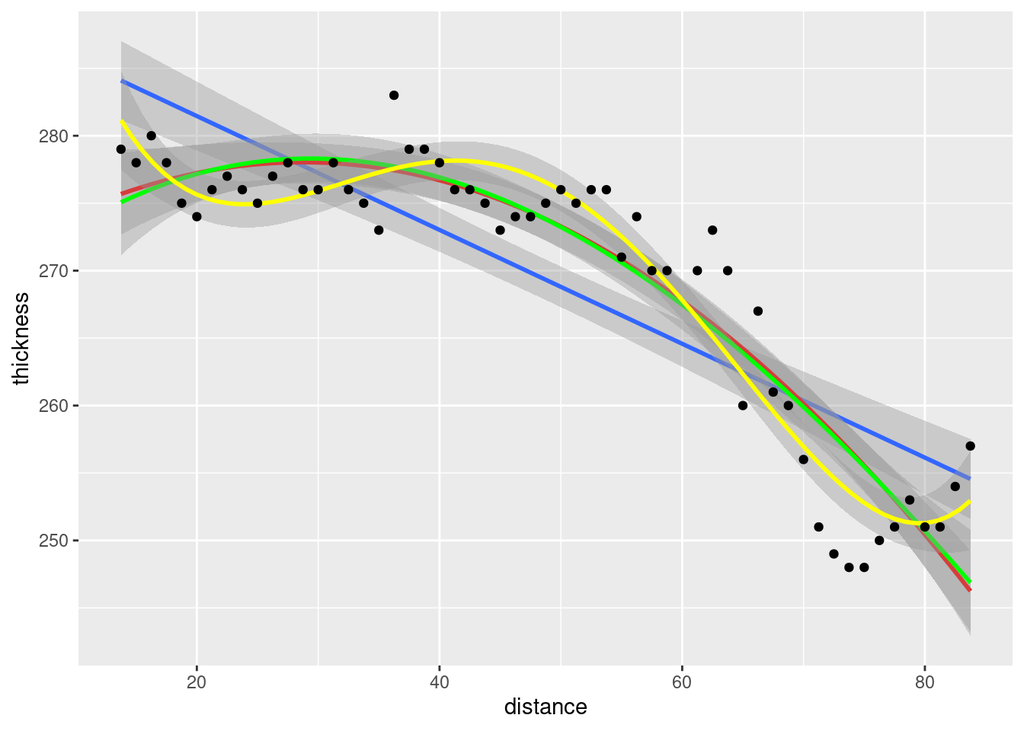

```r
library(ggplot2)
ggplot(geophones, aes(distance, thickness) ) + stat_smooth(method = lm, formula = y ~ poly(x, 1, raw = TRUE)) + stat_smooth(method = lm, formula = y ~ poly(x, 2, raw = TRUE), col="red") + stat_smooth(method = lm, formula = y ~ poly(x, 3, raw = TRUE), col="green") + stat_smooth(method = lm, formula = y ~ poly(x, 4, raw = TRUE), col="yellow") + geom_point()
```

According to the summary of the fitted models, Anova test, AIC, and the plots, we can see the polynomial of degree 4 is the best choice among the four models. However, none of the fitted curves capture the curvature of the data in the region where distance is large.  
Also, increasing the degree of the polynomial is not a good idea cause it can lead to over-fitting. So it is better to use other models such as Generalized Additive Models (GAM)

## Exercise 5 from chapter 11

**This exercise will compare alternative measures of accuracy from randomForest() runs. First, 16 rows where data (on V6) is missing will be omitted:**

```r
library(randomForest)
library(MASS)
sapply(biopsy, function(x)sum(is.na(x)))
```

```
##    ID    V1    V2    V3    V4    V5    V6    V7    V8    V9 class
##     0     0     0     0     0     0    16     0     0     0     0
```

```r
biops <- na.omit(biopsy[,-1]) ## Column 1 is ID
## Examine list element names in randomForest object
names(randomForest(class~ ., data=biops))
```

```
##  [1] "call"            "type"            "predicted"       "err.rate"
##  [5] "confusion"       "votes"           "oob.times"       "classes"
##  [9] "importance"      "importanceSD"    "localImportance" "proximity"
## [13] "ntree"           "mtry"            "forest"          "y"
## [17] "test"            "inbag"           "terms"
```

- **Compare repeated randomForest() runs:**

```r
## Repeated runs, note variation in OOB accuracy.
for(i in 1:10) {
biops.rf <- randomForest(class ~ ., data=biops)
OOBerr <- mean(biops.rf$err.rate[,"OOB"])
print(paste(i, ": ", round(OOBerr, 4), sep=""))
print(round(biops.rf$confusion,4))
}
```

```
## [1] "1: 0.0297"
##           benign malignant class.error
## benign       433        11      0.0248
## malignant      8       231      0.0335
## [1] "2: 0.0303"
##           benign malignant class.error
## benign       432        12      0.0270
## malignant      7       232      0.0293
## [1] "3: 0.029"
##           benign malignant class.error
## benign       433        11      0.0248
## malignant      8       231      0.0335
## [1] "4: 0.0292"
##           benign malignant class.error
## benign       433        11      0.0248
## malignant      7       232      0.0293
## [1] "5: 0.0326"
##           benign malignant class.error
## benign       432        12      0.0270
## malignant      9       230      0.0377
## [1] "6: 0.031"
##           benign malignant class.error
## benign       433        11      0.0248
## malignant      8       231      0.0335
## [1] "7: 0.0298"
##           benign malignant class.error
## benign       433        11      0.0248
## malignant      9       230      0.0377
## [1] "8: 0.0313"
##           benign malignant class.error
## benign       432        12      0.0270
## malignant      7       232      0.0293
## [1] "9: 0.0292"
##           benign malignant class.error
## benign       433        11      0.0248
## malignant      7       232      0.0293
## [1] "10: 0.0281"
##           benign malignant class.error
## benign       432        12      0.0270
## malignant      6       233      0.0251
```

- **Compare OOB accuracies with test set accuracies: plot test set accuracies against OOB accuracies. Add the line y = x to the plot. Is there any consistent difference in the accuracies? Given a random training/test split, is there any reason to expect a consistent difference between OOB accuracy and test accuracy?**

```r
## Repeated train/test splits: OOB accuracy vs test set accuracy.
errors <- matrix(0,ncol=2,nrow=10)
for(i in 1:10){
trRows <- sample(1:dim(biops)[1], size=round(dim(biops)[1]/2))
biops.rf <- randomForest(class ~ ., data=biops[trRows, ],
xtest=biops[-trRows,-10],
ytest=biops[-trRows,10])
oobErr <- mean(biops.rf$err.rate[,"OOB"])
testErr <- mean(biops.rf$test$err.rate[,"Test"])
print(round(c(oobErr,testErr),4))
errors[i,] <-c(oobErr,testErr)
}
```

```
## [1] 0.0383 0.0291
## [1] 0.0388 0.0337
## [1] 0.0357 0.0362
## [1] 0.0247 0.0468
## [1] 0.0321 0.0359
## [1] 0.0378 0.0193
## [1] 0.0324 0.0190
## [1] 0.0379 0.0325
## [1] 0.0453 0.0250
## [1] 0.0332 0.0350
```

```r
errors
```

```
##             [,1]       [,2]
##  [1,] 0.03826271 0.02907918
##  [2,] 0.03880821 0.03368915
##  [3,] 0.03566582 0.03618182
##  [4,] 0.02470748 0.04675660
##  [5,] 0.03210092 0.03590616
##  [6,] 0.03779952 0.01925513
##  [7,] 0.03235895 0.01896774
##  [8,] 0.03787600 0.03253372
##  [9,] 0.04534745 0.02504985
## [10,] 0.03316836 0.03502639
```

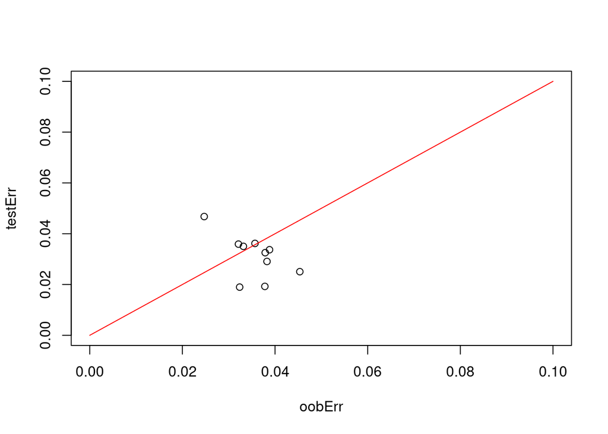

```r
plot(x=errors[,1], y=errors[,2] ,ylab="testErr", xlab="oobErr", xlim=c(0,0.1),ylim = c(0,0.1))
curve(1*x,col="red",add=T)
```

The results show that there is no significant difference between OOB error and Test error in random forest because OOB is calculated based on data points which are not included for building trees; therefore it is unseen and plays like test data.

- **Calculate the error rate for the training data: explain why use of the training data for testing leads to an error rate that is zero.**

```r
randomForest(class ~., data=biops, xtest=biops[,-10],ytest=biops[,10])
```

```
##
## Call:
##  randomForest(formula = class ~ ., data = biops, xtest = biops[,      -10], ytest = biops[, 10])
##                Type of random forest: classification
##                      Number of trees: 500
## No. of variables tried at each split: 3
##
##         OOB estimate of  error rate: 2.93%
## Confusion matrix:
##           benign malignant class.error
## benign       431        13  0.02927928
## malignant      7       232  0.02928870
##                 Test set error rate: 0%
## Confusion matrix:
##           benign malignant class.error
## benign       444         0           0
## malignant      0       239           0
```

Using of the training data for testing leads to an error rate that is zero because random forest builds full trees based on the training data that exactly fit the data (overfitting), so there is no error on the training data.

# Exercise 1

**The General Social Survey (GSS) has been conducted in the United States every two years since 1972.**

#### Choice of the response variable and treatment of missing values

The variable chosen from the General Social Survey is the `CAPPUN` variable. It is related to the following question:

*Does the respondent favor or oppose the death penalty for persons convicted of murder?*

The response has been analyzed as a function of the following predictors: age (`AGE`), sex (`SEX`, with levels $1$ and $2$ for “Male” and “Female”, respectively), education (`EDUC`) and ethnicity (`RACE`, with levels $1$, $2$ and $3$ for “White”, “Black” and “Other”, respectively. This variable has been used in place of `ETHNIC`, since the latter has too many levels).  
The response variable has two levels, coded by default with the numbers $1$, for supporters of the death penalty (Favor), and $2$, for those who oppose this punishment (Oppose). The two levels have been re-scaled to $1$ and $0$, respectively.

```r
library(haven)
path = file.path("/home/macro/Uni/IyIs/SMDS", "H3", "GSS7218_R3.sav")
GSS = read_sav(path)
data <- GSS[,c("YEAR","AGE","SEX","EDUC","RACE","CAPPUN")]

#data from 1974
data <- data[(data$YEAR ==1974 | data$YEAR == 1978 | data$YEAR >= 1982),]

# Shift binary variables
if(!(is.na(data$SEX))) data$SEX <- data$SEX-1
if(!(is.na(data$CAPPUN))) {
  data$CAPPUN <- data$CAPPUN-1
  data$CAPPUN <- -data$CAPPUN+1
}

data$RACE <- factor(data$RACE, c(1,2,3))
levels(data$RACE) <- c("White","Black","Other")
data$SEX <- factor(data$SEX, c(0,1))
levels(data$SEX) <- c("Male","Female")

summary(data)
```

```
##       YEAR           AGE            SEX             EDUC          RACE
##  Min.   :1974   Min.   :18.00   Male  :24433   Min.   : 0.00   White:44036
##  1st Qu.:1988   1st Qu.:32.00   Female:31277   1st Qu.:12.00   Black: 8135
##  Median :1998   Median :44.00                  Median :12.00   Other: 3539
##  Mean   :1998   Mean   :46.32                  Mean   :13.07
##  3rd Qu.:2006   3rd Qu.:59.00                  3rd Qu.:15.00
##  Max.   :2018   Max.   :89.00                  Max.   :20.00
##                 NA's   :192                    NA's   :143
##      CAPPUN
##  Min.   :0.000
##  1st Qu.:0.000
##  Median :1.000
##  Mean   :0.711
##  3rd Qu.:1.000
##  Max.   :1.000
##  NA's   :7764
```

It can be immediately noticed that some values of `AGE`, `EDUC` and `CAPPUN` are missing. The missing values of the numeric variables `AGE` and `EDUC` are to be imputed using the mean, which can be computed using the other available data, while those of the categorical variable `CAPPUN` are imputed using the most frequent value present in the available data. However, since it is required to study some quantities (like the proportion of people in favor in the second point of the exercise) over time, it has been checked that, year by year, the frequency of missing values does not exceed the 20$\%$ of the total values.

```r
# Period over which the variable "CAPPUN" has been studied
n.year <- c(1974,1978,1982:1991,1993,1994,1996,1998,2000,2002,2004,2006,2008,2010,2012,2014,2016,2018)
number.of.years <- length(n.year)

freq.na.AGE <- c()      # Vector of frequencies of AGE's NAs
freq.na.EDUC <- c()     # Vector of frequencies of EDUC's NAs
freq.na.CAPPUN <- c()   # Vector of frequencies of CAPPUN's NAs

# Computation of frequencies of missing values
for(i in 1:number.of.years){
  n <- nrow(data[data$YEAR == n.year[i],])
  freq.na.AGE[i] <- sum(is.na(data$AGE[data$YEAR==n.year[i]]))/n
  freq.na.EDUC[i] <- sum(is.na(data$EDUC[data$YEAR==n.year[i]]))/n
  freq.na.CAPPUN[i] <- sum(is.na(data$CAPPUN[data$YEAR==n.year[i]]))/n
}

# Find frequencies that exceed the imposed limit
too.many.na.AGE <- freq.na.AGE[freq.na.AGE>=0.2]
too.many.na.AGE
```

```
## numeric(0)
```

```r
too.many.na.EDUC <- freq.na.EDUC[freq.na.EDUC>=0.2]
too.many.na.EDUC
```

```
## numeric(0)
```

```r
too.many.na.CAPPUN <- freq.na.CAPPUN[freq.na.CAPPUN>=0.2]
too.many.na.CAPPUN
```

```
## [1] 0.5269439 0.5529872 0.3758315
```

One can notice that `AGE` and `EDUC` have few missing values, while `CAPPUN` has too many missing values occurring in three different years. These years are:

```r
n.year[match(freq.na.CAPPUN[freq.na.CAPPUN>=0.2],freq.na.CAPPUN)]
```

```
## [1] 2002 2004 2006
```

In these cases, imputing missing values using the most frequent one would invalidate the whole set of data related to a specific year. Therefore, for the above years, the rows associated to missing values has been simply removed (by doing this, one removes also the rows with NA(s) associated with `AGE` and `EDUC`, but this is not a problem since they are few).

```r
# Remove missing values from data
data.2002  <- na.omit(data[data$YEAR==2002,])
data.2004  <- na.omit(data[data$YEAR==2004,])
data.2006  <- na.omit(data[data$YEAR==2006,])

# Create dataset where only missing values coming from 2002, 2004 and 2006 are removed
data.02to06 <- rbind(data.2002,data.2004,data.2006)
data.74to00 <- data[(data$YEAR>=1974 & data$YEAR<=2000),]
data.08to18 <- data[data$YEAR>=2008,]
data <- rbind(data.74to00,data.02to06,data.08to18)
```

Then, the data has been completed as explained above.

```r
mean_AGE <- round(mean(data$AGE, na.rm = T)+0.5, digits = 0)
mean_EDUC <- round(mean(data$EDUC, na.rm = T)+0.5, digits = 0)
cappun_favor <- data$CAPPUN[(!(is.na(data$CAPPUN)) & data$CAPPUN==1)]
cappun_oppose <- data$CAPPUN[(!(is.na(data$CAPPUN)) & data$CAPPUN==0)]

data$AGE[is.na(data$AGE)] <- mean_AGE
data$EDUC[is.na(data$EDUC)] <- mean_EDUC

if(length(cappun_favor)>length(cappun_oppose)){
  data$CAPPUN[is.na(data$CAPPUN)] <- 1
} else {
  data$CAPPUN[is.na(data$CAPPUN)] <- 0
}
summary(data)
```

```
##       YEAR           AGE            SEX             EDUC          RACE
##  Min.   :1974   Min.   :18.00   Male  :22365   Min.   : 0.00   White:40456
##  1st Qu.:1987   1st Qu.:32.00   Female:28614   1st Qu.:12.00   Black: 7411
##  Median :1996   Median :44.00                  Median :12.00   Other: 3112
##  Mean   :1998   Mean   :46.31                  Mean   :13.04
##  3rd Qu.:2008   3rd Qu.:59.00                  3rd Qu.:15.00
##  Max.   :2018   Max.   :89.00                  Max.   :20.00
##      CAPPUN
##  Min.   :0.0000
##  1st Qu.:0.0000
##  Median :1.0000
##  Mean   :0.7279
##  3rd Qu.:1.0000
##  Max.   :1.0000
```

```r
# Save for graphs later
data$CAPPUN.BIN <- data$CAPPUN
```

#### Behavior of `CAPPUN` over time

One can give a graph of the average response of the binary response variable `CAPPUN` over time.

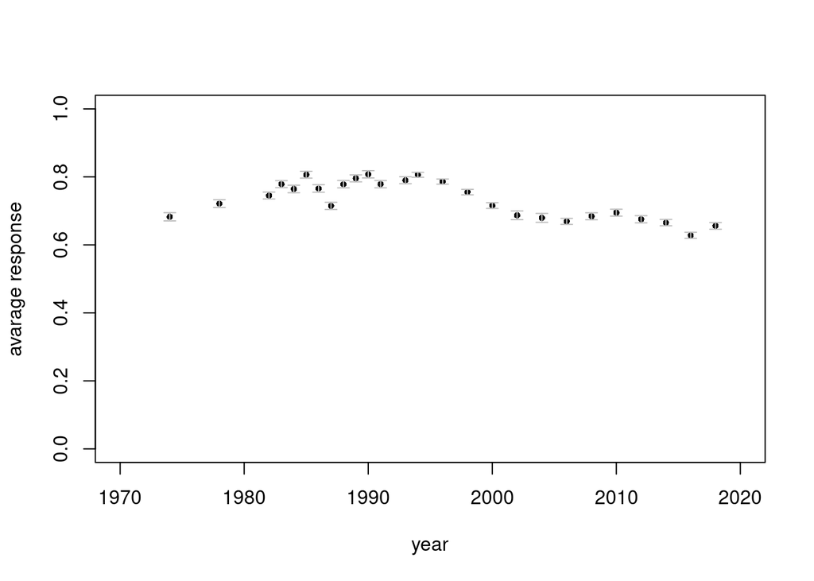

```r
CAPPUN_time.avg <- c()  # Vector containing average response per year
se <- c()               # Vector of standard error

# Computation of CAPPUN's proportion over time
for(i in 1:number.of.years){
  CAPPUN_time.avg[i] <- mean(data$CAPPUN[data$YEAR == n.year[i]],na.rm=T)

  n <- nrow(data[data$YEAR == n.year[i],])
  s <- CAPPUN_time.avg[i]*(1-CAPPUN_time.avg[i])
  se[i] <- sqrt(s/n)
}

# Plot with standard error bounds
plot(n.year, CAPPUN_time.avg, xlab = "year", ylab = "avarage response", xlim = c(1970,2020), ylim = c(0,1), pch=16, cex=0.7)
arrows(x0=n.year, y0=CAPPUN_time.avg-se, x1=n.year, y1=CAPPUN_time.avg+se, code=3, angle=90, length=0.05, col="grey")
```

From the graph above, one can notice a trend toward an opinion in favor of the capital punishment for those convicted of murder during the first decades in which the survey was conducted, then growing slowing toward the opposite opinion after 2000, but still with the majority of the people in favor of the death penalty.

#### Logistic regression

Now, a logistic regression of the response variable `CAPPUN` can be set up, given the four predictors `AGE`, `SEX`, `EDUC` and `RACE`. We start with a model that does not include any interaction between predictors.

```r
fit0 <- glm(CAPPUN ~ AGE + SEX + EDUC + RACE, family = binomial(link = "logit"), data = data)
summary(fit0)
```

```
##
## Call:
## glm(formula = CAPPUN ~ AGE + SEX + EDUC + RACE, family = binomial(link = "logit"),
##     data = data)
##
## Deviance Residuals:
##     Min       1Q   Median       3Q      Max
## -2.0867  -1.1694   0.6898   0.7637   1.3527
##
## Coefficients:
##               Estimate Std. Error z value Pr(>|z|)
## (Intercept)  2.0948002  0.0599278  34.955   <2e-16 ***
## AGE         -0.0011489  0.0005977  -1.922   0.0546 .
## SEXFemale   -0.3512672  0.0208734 -16.828   <2e-16 ***
## EDUC        -0.0467477  0.0033734 -13.858   <2e-16 ***
## RACEBlack   -1.1358617  0.0266725 -42.586   <2e-16 ***
## RACEOther   -0.6939549  0.0397384 -17.463   <2e-16 ***
## ---
## Signif. codes:  0 '***' 0.001 '**' 0.01 '*' 0.05 '.' 0.1 ' ' 1
##
## (Dispersion parameter for binomial family taken to be 1)
##
##     Null deviance: 59677  on 50978  degrees of freedom
## Residual deviance: 57352  on 50973  degrees of freedom
## AIC: 57364
##
## Number of Fisher Scoring iterations: 4
```

According to this model, the predictor `AGE` is not statistically significant. This is not surprising, since it is somehow expected that people’s opinion on this matter depends on other factors, such as education or the fact of being from different ethnicities, if belonging to some of them results in a higher chance of being punished by death, if murder is committed.  
One can study the trend of the estimates of the coefficients over time, computing them for each year.

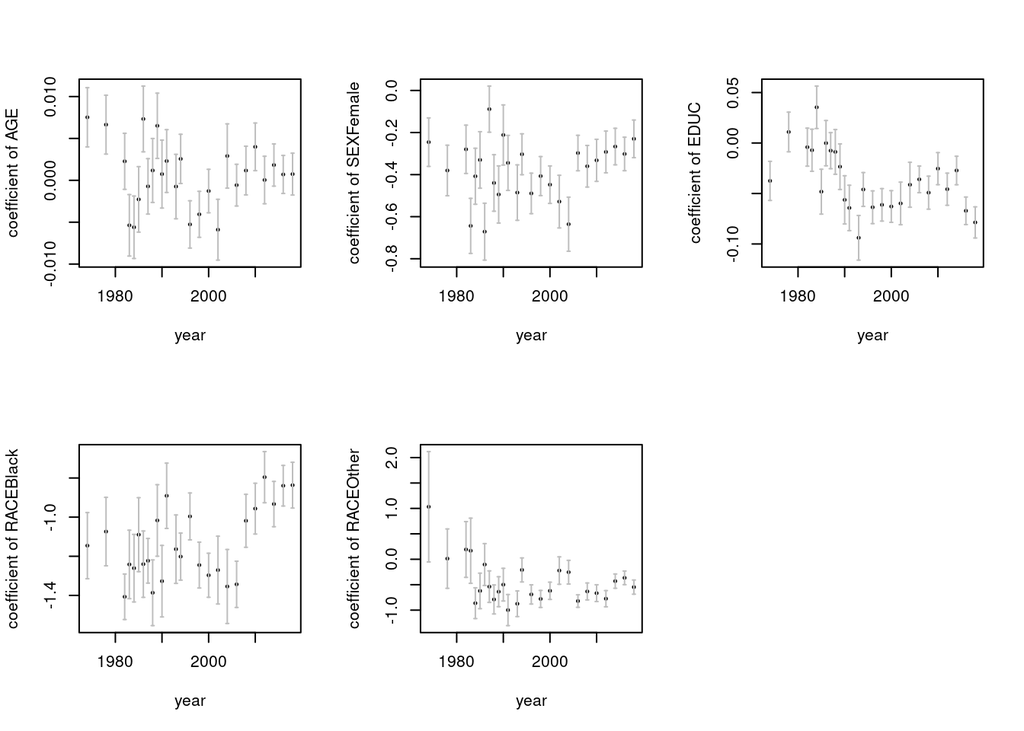

```r
coefs.ma <- matrix(NA, nrow = number.of.years, ncol = 6)
SE_coefs.ma <- matrix(NA, nrow = number.of.years, ncol = 6)
for(i in 1:number.of.years){
  fit <- glm(CAPPUN ~ AGE + SEX + EDUC + RACE, family = binomial(link = "logit"), data = data[data$YEAR == n.year[i],])
  coefs.ma[i,] <- fit$coefficients
  SE_coefs.ma[i,] <- summary(fit)$coefficients[,2]
}

colnames(coefs.ma) <- c("intercept","coefficient of AGE","coefficient of SEXFemale","coefficient of EDUC","coefficient of RACEBlack","coefficient of RACEOther")

par(mfrow=c(2,3))
for(i in 2:6){
  plot(n.year, coefs.ma[,i], ylab = colnames(coefs.ma)[i], xlab = "year",pch=20,cex=.5, ylim =   c(min(coefs.ma[,i]-SE_coefs.ma[,i]),max(coefs.ma[,i]+SE_coefs.ma[,i])))
  arrows(x0=n.year, y0=coefs.ma[,i]-SE_coefs.ma[,i], x1=n.year, y1=coefs.ma[,i]+SE_coefs.ma[,i], code=3, angle=90, length=0.01, col="grey")
}
```

#### Tree-based classification

Using the 4 variables `AGE`, `SEX`, `EDUC` and `RACE`, it is possible to built a decision tree that is able to classify each answer, “favor” or “oppose”.

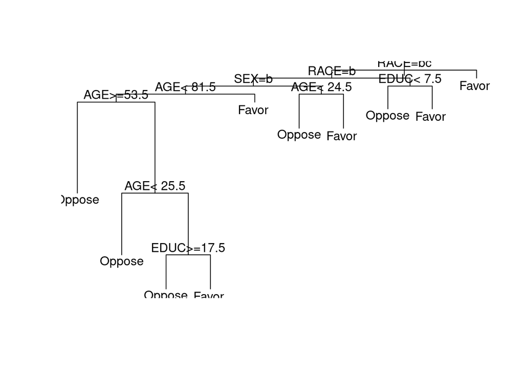

```r
library(reshape2)
library(rpart)
library(rpart.plot)

# Treat `CAPPUN` as factor
data$CAPPUN <- factor(data$CAPPUN, levels=c(0, 1))
levels(data$CAPPUN) <- c("Oppose","Favor")

tree_data <- rpart(CAPPUN ~ AGE + SEX + EDUC + RACE, method="class", data=as.data.frame(data), cp=0.0008)
plot(tree_data)
text(tree_data)
```

We now build the largest tree possible, setting $cp=0$, and then we prune it in order to obtain the best number of splits. First, we check the behavior of the cross validation error.

```r
tree.largest_data <- rpart(CAPPUN ~ AGE + SEX + EDUC + RACE, method="class", data=as.data.frame(data), cp=0)
printcp(tree.largest_data)
```

```
##
## Classification tree:
## rpart(formula = CAPPUN ~ AGE + SEX + EDUC + RACE, data = as.data.frame(data),
##     method = "class", cp = 0)
##
## Variables actually used in tree construction:
## [1] AGE  EDUC RACE SEX
##
## Root node error: 13870/50979 = 0.27207
##
## n= 50979
##
##            CP nsplit rel error  xerror      xstd
## 1  9.2526e-04      0   1.00000 1.00000 0.0072445
## 2  7.4501e-04      9   0.98919 1.00144 0.0072477
```

[output cut: 38 more lines]

The plot of the cross validation error against the cp value is the following.

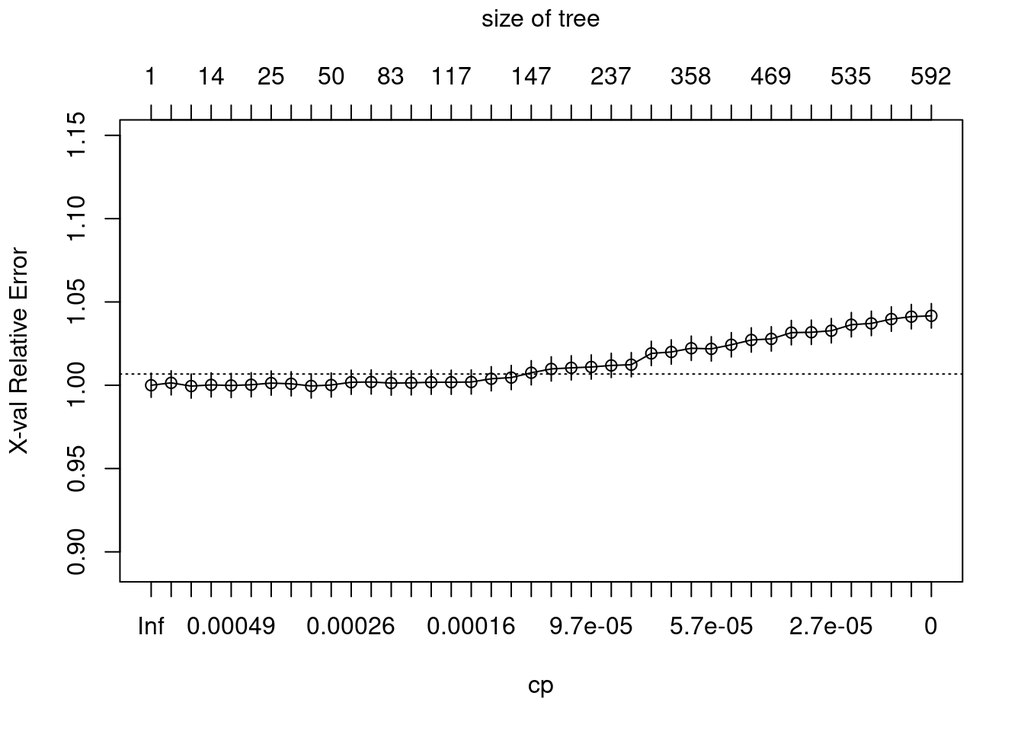

```r
plotcp(tree.largest_data)
```

It is possible to notice that the `xerror` has an almost constant behavior for a few iterations and then it increases quite rapidly due to strong over-fitting. A `cptable` like the one obtained above should be interpreted as a warning that the computed tree is of little use because probably it will not be able to generalize on other data. At this point, the best thing to do is to select the tree with the lowest associated cross validation error, because the optimal tree, i.e. the smallest tree with cross validation error lower than the sum of the minimum `xerror` and the associated `xstd`, can be found at the root.  
The best complexity parameter is given by:

```r
best.cp <- tree.largest_data$cptable[which.min(tree.largest_data$cptable[,"xerror"]),]
best.cp
```

```
##           CP       nsplit    rel error       xerror         xstd
## 7.209805e-04 1.200000e+01 9.869503e-01 9.994953e-01 7.243310e-03
```

Then, the best tree is given by:

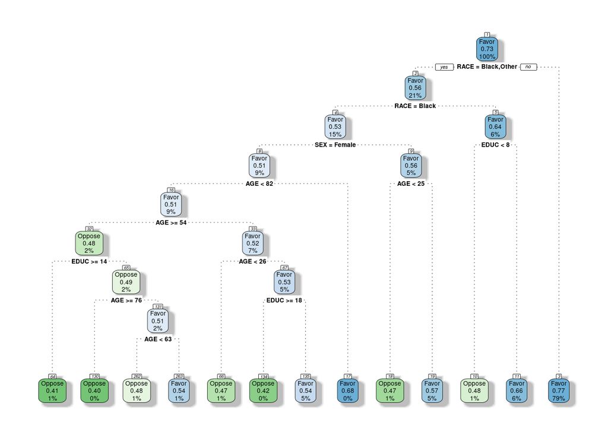

```r
tree.pruned <- prune(tree.largest_data, cp=best.cp[1])
rpart.plot(tree.pruned, extra=106, box.palette="GnBu",branch.lty=3, shadow.col="gray", nn=TRUE)
```

```r
printcp(tree.pruned)
```

```
##
## Classification tree:
## rpart(formula = CAPPUN ~ AGE + SEX + EDUC + RACE, data = as.data.frame(data),
##     method = "class", cp = 0)
##
## Variables actually used in tree construction:
## [1] AGE  EDUC RACE SEX
##
## Root node error: 13870/50979 = 0.27207
##
## n= 50979
##
##           CP nsplit rel error xerror      xstd
## 1 0.00092526      0   1.00000 1.0000 0.0072445
## 2 0.00074501      9   0.98919 1.0014 0.0072477
## 3 0.00072098     12   0.98695 0.9995 0.0072433
```

In this case, the absolute cross validation error is given by:

```r
cv.err <- min(tree.pruned$cptable[,"xerror"]) * 0.27207
cv.err
```

```
## [1] 0.2719327
```

This gives the model an error rate of:

```r
cv.err*100
```

```
## [1] 27.19327
```

#### Model expansion

In order to answer social science questions of interest, one can expand the model by adding interactions between the predictors, so that it is possible to analyze the effect of one variable on the others. In order to make the interpretation of the coefficients more clear, `AGE` has been divided by ten, so that variations of the new variable are measured in units of decades, and `EDUC` has been divided by four. The full model is the following.

```r
data$AGE10 <- data$AGE/10
data$EDUC4 <- data$EDUC/4
fit.exp <- glm(CAPPUN ~ AGE10 + SEX + EDUC4 + RACE + AGE10:SEX + AGE10:EDUC4 + AGE10:RACE + SEX:EDUC4 + SEX:RACE + EDUC4:RACE, family = binomial(link = "logit"), data = data)
summary(fit.exp)
```

```
##
## Call:
## glm(formula = CAPPUN ~ AGE10 + SEX + EDUC4 + RACE + AGE10:SEX +
##     AGE10:EDUC4 + AGE10:RACE + SEX:EDUC4 + SEX:RACE + EDUC4:RACE,
##     family = binomial(link = "logit"), data = data)
##
## Deviance Residuals:
##     Min       1Q   Median       3Q      Max
## -2.2789  -1.1964   0.6793   0.7803   1.2867
##
## Coefficients:
##                      Estimate Std. Error z value Pr(>|z|)
## (Intercept)          2.627510   0.164374  15.985  < 2e-16 ***
## AGE10               -0.032822   0.027658  -1.187 0.235345
## SEXFemale           -0.171477   0.119499  -1.435 0.151297
## EDUC4               -0.377827   0.045640  -8.278  < 2e-16 ***
## RACEBlack           -2.169088   0.152807 -14.195  < 2e-16 ***
## RACEOther           -2.409233   0.191738 -12.565  < 2e-16 ***
## AGE10:SEXFemale     -0.058110   0.012462  -4.663 3.12e-06 ***
## AGE10:EDUC4          0.016792   0.007761   2.164 0.030487 *
## AGE10:RACEBlack      0.025399   0.016335   1.555 0.119982
## AGE10:RACEOther      0.014245   0.026408   0.539 0.589603
## SEXFemale:EDUC4      0.003545   0.027337   0.130 0.896825
## SEXFemale:RACEBlack  0.245775   0.055107   4.460 8.20e-06 ***
## SEXFemale:RACEOther  0.290423   0.080032   3.629 0.000285 ***
## EDUC4:RACEBlack      0.239001   0.035481   6.736 1.63e-11 ***
## EDUC4:RACEOther      0.463626   0.042432  10.926  < 2e-16 ***
## ---
## Signif. codes:  0 '***' 0.001 '**' 0.01 '*' 0.05 '.' 0.1 ' ' 1
##
## (Dispersion parameter for binomial family taken to be 1)
##
##     Null deviance: 59677  on 50978  degrees of freedom
## Residual deviance: 57151  on 50964  degrees of freedom
## AIC: 57181
##
## Number of Fisher Scoring iterations: 4
```

From the results above, we understand that `AGE`, `SEX`, the interaction between age and race `AGE:RACE` and the one between sex and education `SEX:EDUC` are not significant.  
We can give the following interpretation for the coefficients calculated above:

- At the mean value of age, for a male of white “race”, adding four years of education results approximately in a $4.9\%$ negative difference in the probability that a person expresses a favorable opinion towards the death penalty.

```r
invlogit <- function (x) {1/(1+exp(-x))}

invlogit(fit.exp$coefficients%*%c(1,mean(data$AGE10),0,mean(data$EDUC4)+1,0,0,mean(data$AGE10)*0,mean(data$AGE10)*(mean(data$EDUC4)+1),mean(data$AGE10)*0,mean(data$AGE10)*0,0*(mean(data$EDUC4)+1),0*0,0*0,(mean(data$EDUC4)+1)*0,(mean(data$EDUC4)+1)*0))-invlogit(fit.exp$coefficients%*%c(1,mean(data$AGE10),0,mean(data$EDUC4),0,0,mean(data$AGE10)*0,mean(data$AGE10)*(mean(data$EDUC4)),mean(data$AGE10)*0,mean(data$AGE10)*0,0*(mean(data$EDUC4)),0*0,0*0,(mean(data$EDUC4))*0,(mean(data$EDUC4))*0))
```

```
##             [,1]
## [1,] -0.04913409
```

- At the mean value of education, for a male of white “race”, adding a decade to his age results approximately in a $0.33\%$ positive difference difference in the probability that a person expresses a favorable opinion towards the death penalty.

```r
invlogit(fit.exp$coefficients%*%c(1,mean(data$AGE10)+1,0,mean(data$EDUC4),0,0,(mean(data$AGE10)+1)*0,(mean(data$AGE10)+1)*mean(data$EDUC4),(mean(data$AGE10)+1)*0,(mean(data$AGE10)+1)*0,0*mean(data$EDUC4),0*0,0*0,mean(data$EDUC4)*0,mean(data$EDUC4)*0))-invlogit(fit.exp$coefficients%*%c(1,mean(data$AGE10),0,mean(data$EDUC4),0,0,mean(data$AGE10)*0,mean(data$AGE10)*(mean(data$EDUC4)),mean(data$AGE10)*0,mean(data$AGE10)*0,0*(mean(data$EDUC4)),0*0,0*0,(mean(data$EDUC4))*0,(mean(data$EDUC4))*0))
```

```
##             [,1]
## [1,] 0.003250292
```

One can also ask what happens if sex or race are changed.

- At the mean age and education levels, switching sex corresponds to an approximate $7.3\%$ negative difference in the probability of having a favorable opinion.

```r
invlogit(fit.exp$coefficients%*%c(1,mean(data$AGE10),1,mean(data$EDUC4),0,0,mean(data$AGE10)*1,mean(data$AGE10)*mean(data$EDUC4),mean(data$AGE10)*0,mean(data$AGE10)*0,1*mean(data$EDUC4),1*0,1*0,(mean(data$EDUC4))*0,(mean(data$EDUC4))*0))-invlogit(fit.exp$coefficients%*%c(1,mean(data$AGE10),0,mean(data$EDUC4),0,0,mean(data$AGE10)*0,mean(data$AGE10)*(mean(data$EDUC4)),mean(data$AGE10)*0,mean(data$AGE10)*0,0*(mean(data$EDUC4)),0*0,0*0,(mean(data$EDUC4))*0,(mean(data$EDUC4))*0))
```

```
##             [,1]
## [1,] -0.07289699
```

- At the mean age and education levels, switching from a white man to a black man’s opinion corresponds to an approximate $26\%$ negative difference in the probability of having a favorable opinion.

```r
invlogit(fit.exp$coefficients%*%c(1,mean(data$AGE10),0,mean(data$EDUC4),1,0,mean(data$AGE10)*0,mean(data$AGE10)*(mean(data$EDUC4)),mean(data$AGE10)*1,mean(data$AGE10)*0,0*(mean(data$EDUC4)),0*1,0*0,(mean(data$EDUC4))*1,(mean(data$EDUC4))*0))-invlogit(fit.exp$coefficients%*%c(1,mean(data$AGE10),0,mean(data$EDUC4),0,0,mean(data$AGE10)*0,mean(data$AGE10)*(mean(data$EDUC4)),mean(data$AGE10)*0,mean(data$AGE10)*0,0*(mean(data$EDUC4)),0*0,0*0,(mean(data$EDUC4))*0,(mean(data$EDUC4))*0))
```

```
##            [,1]
## [1,] -0.2611795
```

- At the mean age and education levels, switching from a man of white ethnicity to a man of ethnicity different from “white” and “black” corresponds to an approximate $16\%$ negative difference in the probability of having a favorable opinion.

```r
invlogit(fit.exp$coefficients%*%c(1,mean(data$AGE10),0,mean(data$EDUC4),0,1,mean(data$AGE10)*0,mean(data$AGE10)*(mean(data$EDUC4)),mean(data$AGE10)*0,mean(data$AGE10)*1,0*(mean(data$EDUC4)),0*0,0*1,(mean(data$EDUC4))*0,(mean(data$EDUC4))*1))-invlogit(fit.exp$coefficients%*%c(1,mean(data$AGE10),0,mean(data$EDUC4),0,0,mean(data$AGE10)*0,mean(data$AGE10)*(mean(data$EDUC4)),mean(data$AGE10)*0,mean(data$AGE10)*0,0*(mean(data$EDUC4)),0*0,0*0,(mean(data$EDUC4))*0,(mean(data$EDUC4))*0))
```

```
##            [,1]
## [1,] -0.1567316
```

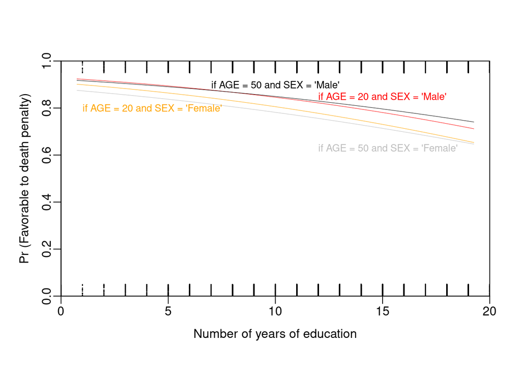

```r
## Graphing the fitted model

jitter.binary <- function(a, jitt=.05){
  ifelse (a==0, runif(length(a), 0, jitt), runif(length(a), 1-jitt, 1))
}

switch.jitter <- jitter.binary(data$CAPPUN.BIN)

plot(data$EDUC, switch.jitter, xlim=c(0,max(data$EDUC)),
     xlab="Number of years of education", ylab="Pr (Favorable to death penalty)",
     type="n", xaxs="i", yaxs="i", mgp=c(2,.5,0), ylim=c(0,1))
curve(invlogit(cbind(1, 20/10, 0, x/4, 0, 0, 0*20/10, (20/10)*(x/4), 0*20/10, 0*20/10, 0*x/4, 0, 0, 0*x/4, 0*x/4) %*% coef(fit.exp)), lwd=.5, add=TRUE, col="red")
curve(invlogit(cbind(1, 50/10, 0, x/4, 0, 0, 0*50/10, (50/10)*(x/4), 0*50/10, 0*50/10, 0*x/4, 0, 0, 0*x/4, 0*x/4) %*% coef(fit.exp)), lwd=.5, add=TRUE)
curve(invlogit(cbind(1, 20/10, 1, x/4, 0, 0, 1*20/10, (20/10)*(x/4), 0*20/10, 0*20/10, 1*x/4, 1*0, 1*0, 0*x/4, 0*x/4) %*% coef(fit.exp)), lwd=.5, add=TRUE, col="orange")
curve(invlogit(cbind(1, 50/10, 1, x/4, 0, 0, 1*50/10, (50/10)*(x/4), 0*50/10, 0*50/10, 1*x/4, 1*0, 1*0, 0*x/4, 0*x/4) %*% coef(fit.exp)), lwd=.5, add=TRUE, col="grey")
points(data$EDUC, jitter.binary(data$CAPPUN.BIN), pch=20, cex=.01)
text(12, .85, "if AGE = 20 and SEX = 'Male'", adj=0, cex=.8, col="red")
text(7, .9, "if AGE = 50 and SEX = 'Male'", adj=0, cex=.8)
text(1, .8, "if AGE = 20 and SEX = 'Female'", adj=0, cex=.8, col="orange")
text(12, .63, "if AGE = 50 and SEX = 'Female'", adj=0, cex=.8, col="grey")
```

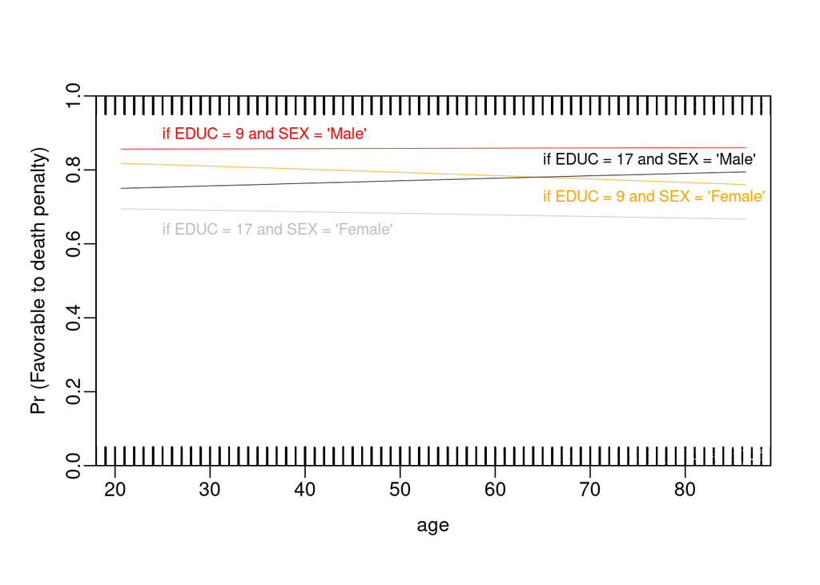

```r
plot(data$EDUC, switch.jitter, xlim=c(min(data$AGE),max(data$AGE)),
     xlab="age", ylab="Pr (Favorable to death penalty)",
     type="n", xaxs="i", yaxs="i", mgp=c(2,.5,0), ylim=c(0,1))
curve(invlogit(cbind(1, x/10, 0, (mean(data$EDUC)-4)/4, 0, 0, 0*x/10, (x/10)*((mean(data$EDUC)-4)/4), 0*x/10, 0*x/10, 0*(mean(data$EDUC)-4)/4, 0, 0, 0*(mean(data$EDUC)-4)/4, 0*(mean(data$EDUC)-4)/4) %*% coef(fit.exp)), lwd=.5, add=TRUE, col="red")
curve(invlogit(cbind(1, x/10, 1, (mean(data$EDUC)-4)/4, 0, 0, 1*x/10, (x/10)*((mean(data$EDUC)-4)/4), 0*x/10, 0*x/10, 1*(mean(data$EDUC)-4)/4, 1*0, 1*0, 0*(mean(data$EDUC)-4)/4, 0*(mean(data$EDUC)-4)/4) %*% coef(fit.exp)), lwd=.5, add=TRUE, col="orange")
curve(invlogit(cbind(1, x/10, 0, (mean(data$EDUC)+4)/4, 0, 0, 0*x/10, (x/10)*((mean(data$EDUC)+4)/4), 0*x/10, 0*x/10, 0*(mean(data$EDUC)+4)/4, 0, 0, 0*(mean(data$EDUC)+4)/4, 0*(mean(data$EDUC)+4)/4) %*% coef(fit.exp)), lwd=.5, add=TRUE)
curve(invlogit(cbind(1, x/10, 1, (mean(data$EDUC)+4)/4, 0, 0, 1*x/10, (x/10)*((mean(data$EDUC)+4)/4), 0*x/10, 0*x/10, 1*(mean(data$EDUC)+4)/4, 1*0, 1*0, 0*(mean(data$EDUC)+4)/4, 0*(mean(data$EDUC)+4)/4) %*% coef(fit.exp)), lwd=.5, add=TRUE, col="grey")
points(data$AGE, jitter.binary(data$CAPPUN.BIN), pch=20, cex=.01)
text(25, .9, "if EDUC = 9 and SEX = 'Male'", adj=0, cex=.8, col="red")
text(65, .83, "if EDUC = 17 and SEX = 'Male'", adj=0, cex=.8)
text(65, .73, "if EDUC = 9 and SEX = 'Female'", adj=0, cex=.8, col="orange")
text(25, .64, "if EDUC = 17 and SEX = 'Female'", adj=0, cex=.8, col="grey")
```

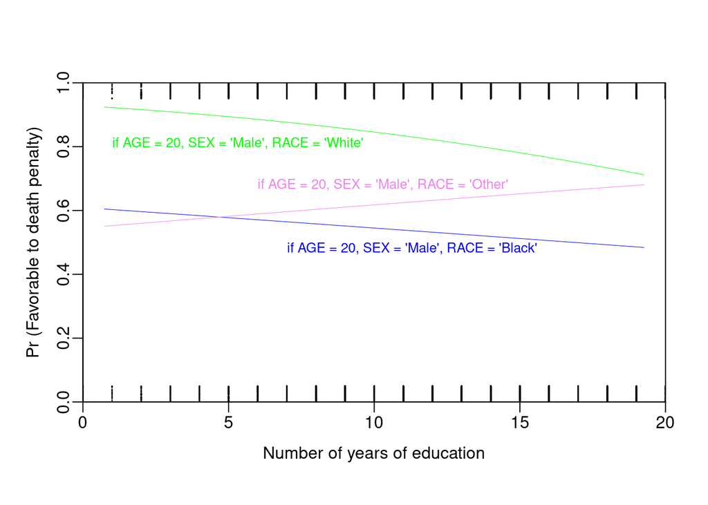

```r
## Graphing the fitted model

plot(data$EDUC, switch.jitter, xlim=c(0,max(data$EDUC)),
     xlab="Number of years of education", ylab="Pr (Favorable to death penalty)",
     type="n", xaxs="i", yaxs="i", mgp=c(2,.5,0), ylim=c(0,1))
curve(invlogit(cbind(1, 20/10, 0, x/4, 0, 0, 0*20/10, (20/10)*(x/4), 0*20/10, 0*20/10, 0*x/4, 0, 0, 0*x/4, 0*x/4) %*% coef(fit.exp)), lwd=.5, add=TRUE, col="green")
curve(invlogit(cbind(1, 20/10, 0, x/4, 1, 0, 0*20/10, (20/10)*(x/4), 1*20/10, 0*20/10, 0*x/4, 0*1, 0*0, 1*x/4, 0*x/4) %*% coef(fit.exp)), lwd=.5, add=TRUE, col="blue")
curve(invlogit(cbind(1, 20/10, 0, x/4, 0, 1, 0*20/10, (20/10)*(x/4), 0*20/10, 1*20/10, 0*x/4, 0*0, 0*1, 0*x/4, 1*x/4) %*% coef(fit.exp)), lwd=.5, add=TRUE, col="violet")
points(data$EDUC, jitter.binary(data$CAPPUN.BIN), pch=20, cex=.01)
text(1, .81, "if AGE = 20, SEX = 'Male', RACE = 'White'", adj=0, cex=.8, col="green")
text(7, .48, "if AGE = 20, SEX = 'Male', RACE = 'Black'", adj=0, cex=.8, col="blue")
text(6, .68, "if AGE = 20, SEX = 'Male', RACE = 'Other'", adj=0, cex=.8, col="violet")
```

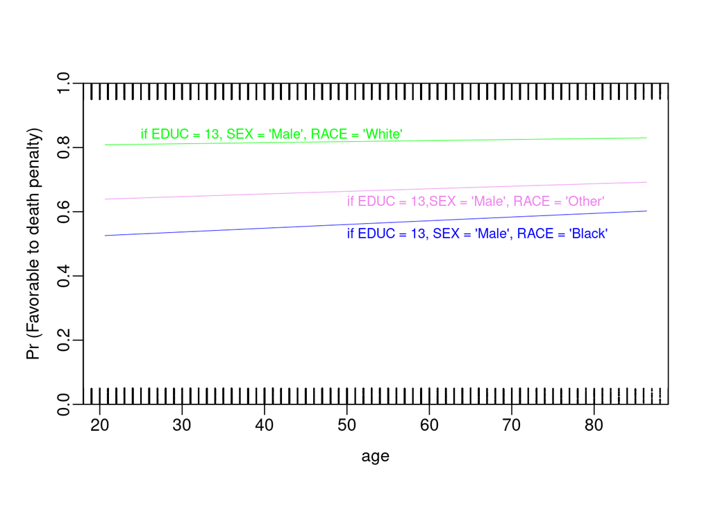

```r
plot(data$EDUC, switch.jitter, xlim=c(min(data$AGE),max(data$AGE)),
     xlab="age", ylab="Pr (Favorable to death penalty)",
     type="n", xaxs="i", yaxs="i", mgp=c(2,.5,0), ylim=c(0,1))
curve(invlogit(cbind(1, x/10, 0, (mean(data$EDUC))/4, 0, 0, 0*x/10, (x/10)*((mean(data$EDUC))/4), 0*x/10, 0*x/10, 0*(mean(data$EDUC))/4, 0, 0, 0*(mean(data$EDUC))/4, 0*(mean(data$EDUC))/4) %*% coef(fit.exp)), lwd=.5, add=TRUE, col="green")
curve(invlogit(cbind(1, x/10, 0, (mean(data$EDUC))/4, 1, 0, 0*x/10, (x/10)*((mean(data$EDUC))/4), 1*x/10, 0*x/10, 0*(mean(data$EDUC))/4, 0*1, 0*0, 1*(mean(data$EDUC))/4, 0*(mean(data$EDUC))/4) %*% coef(fit.exp)), lwd=.5, add=TRUE, col="blue")
curve(invlogit(cbind(1, x/10, 0, (mean(data$EDUC))/4, 0, 1, 0*x/10, (x/10)*((mean(data$EDUC))/4), 0*x/10, 1*x/10, 0*(mean(data$EDUC))/4, 0*0, 0*1, 0*(mean(data$EDUC))/4, 1*(mean(data$EDUC))/4) %*% coef(fit.exp)), lwd=.5, add=TRUE, col="violet")
points(data$AGE, jitter.binary(data$CAPPUN.BIN), pch=20, cex=.01)
text(25, .84, "if EDUC = 13, SEX = 'Male', RACE = 'White'", adj=0, cex=.8, col="green")
text(50, .53, "if EDUC = 13, SEX = 'Male', RACE = 'Black'", adj=0, cex=.8, col="blue")
text(50, .63, "if EDUC = 13,SEX = 'Male', RACE = 'Other'", adj=0, cex=.8, col="violet")
```

Also from the plots above, we can deduce that the variable `AGE` does not play an important role, as expected.

# Exercise 2

**The file risky_behaviors.dta contains data from a randomized trial targeting couples at high risk of HIV infection. The intervention provided counseling sessions regarding practices that could reduce their likelihood of contracting HIV. Couples were randomized either to a control group (women_alone = no woman counselling and *couples = no couple counselling), a group in which just the woman participated (women_alone = only woman counselling and couples = no couple counselling), or a group in which both members of the couple participated (women_alone = no woman counselling and couples = couple counselling). Some variables are collected at the beginning of the study:  
**-** sex the gender of the interviewed member of the couple that reported sex acts;  
**-** bs_hiv if the interviewed member was HIV-positive before the study; **-** bupacts the number of unprotected sex acts before the study. One of the outcomes examined after three months was “number of unprotected sex acts at the end of the study” fupacts.  
Model this outcome as a function of treatment assignment using a Poisson regression. Does the model fit well? Is there evidence of overdispersion?**

```r
#load the data and set up for the analysis
library(foreign)
data <- read.dta("risky_behaviors.dta")
#data
data$couples <- factor(data$couples) ## counselling session to couples
levels(data$couples) <-  c("no couple counselling", "couple conselling")
data$women_alone <- factor(data$women_alone) ## counselling session only to women
levels(data$women_alone) <-  c("no woman counselling","only woman counselling")
data$fupacts <- round(data$fupacts)
#data
summary(data)
```

```
##     sex                       couples                    women_alone
##  woman:217   no couple counselling:272   no woman counselling  :288
##  man  :217   couple conselling    :162   only woman counselling:146
##
##
##
##
##       bs_hiv       bupacts          fupacts
##  negative:337   Min.   :  0.00   Min.   :  0.00
##  positive: 97   1st Qu.:  5.00   1st Qu.:  0.00
##                 Median : 15.00   Median :  5.00
##                 Mean   : 25.91   Mean   : 16.49
##                 3rd Qu.: 36.00   3rd Qu.: 21.00
##                 Max.   :300.00   Max.   :200.00
```

```r
#looking at the data
risky <- data
risky2 <- data

risky2$sex <- ifelse(risky2$sex == "woman",1,0)
risky2$bs_hiv <- ifelse(risky2$bs_hiv == "positive",1,0)
risky2$couples <- ifelse(risky2$couples == "couple conselling",1,0)
risky2$women_alone <- ifelse(risky2$women_alone == "only woman counselling",1,0)

library(PerformanceAnalytics)
```

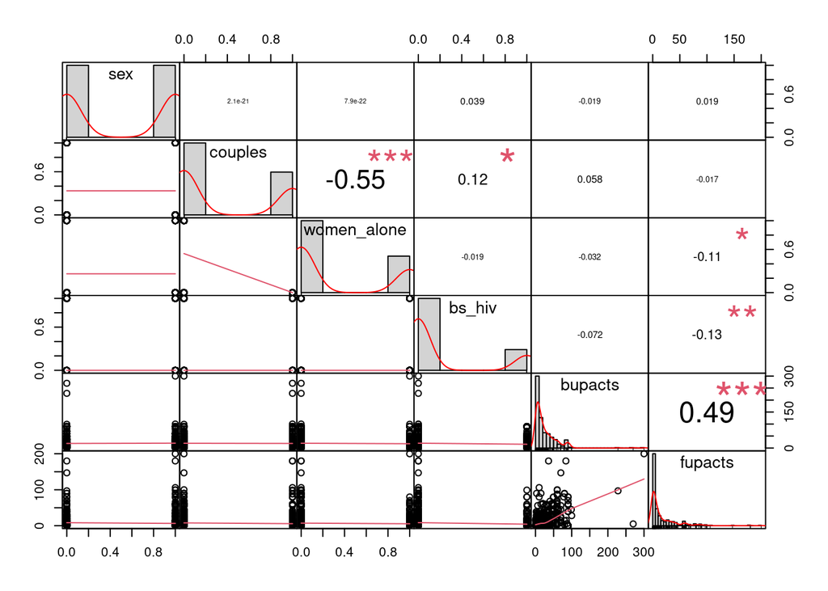

```r
chart.Correlation(risky2[, c("sex", "couples", "women_alone", "bs_hiv", "bupacts", "fupacts")])
```

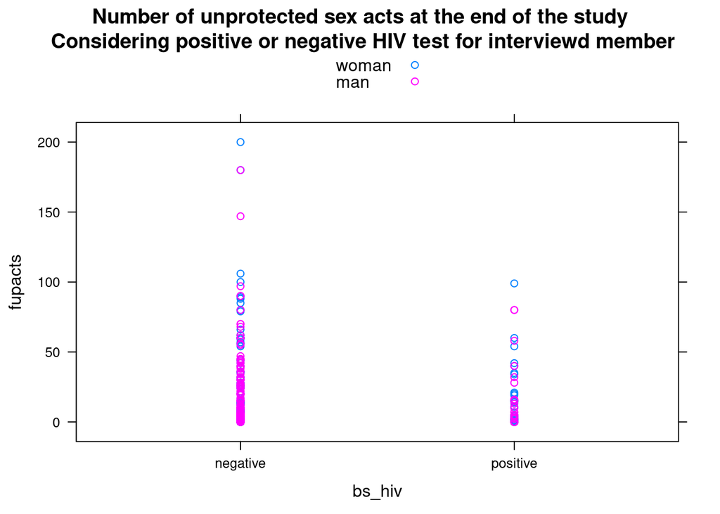

```r
xyplot(fupacts ~ bs_hiv, groups=sex, data=risky, auto.key = TRUE, main="Number of unprotected sex acts at the end of the study\n Considering positive or negative HIV test for interviewd member")
```

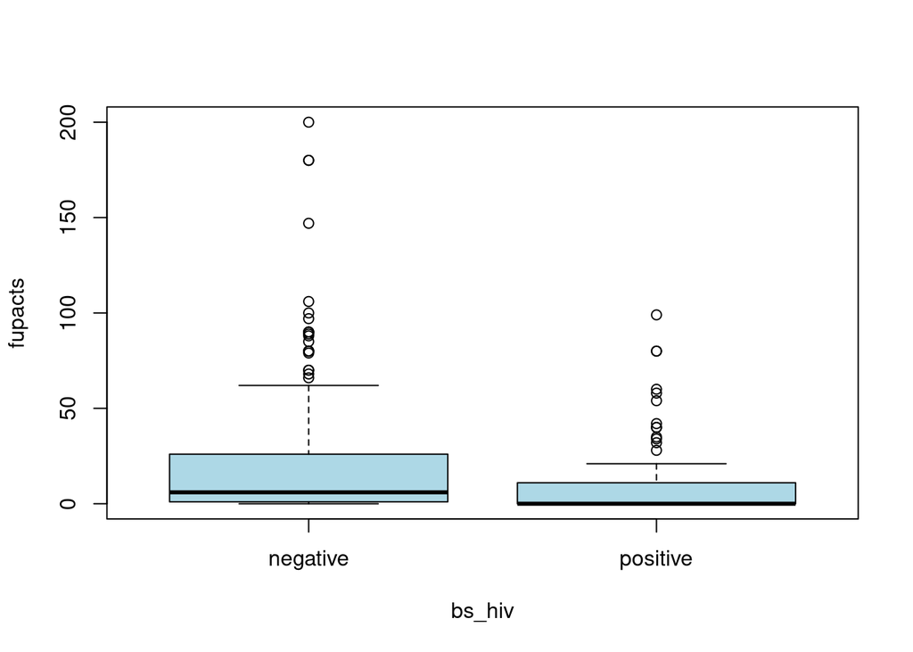

```r
plot(risky$fupacts~risky$bs_hiv, ylab="fupacts", xlab="bs_hiv", col="lightblue")
```

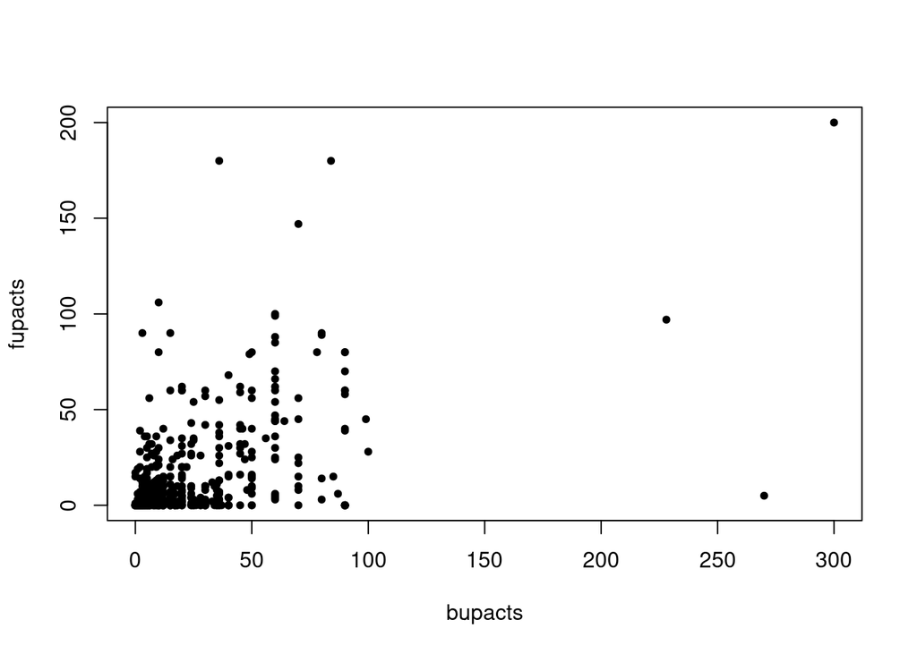

```r
plot(risky$fupacts ~ risky$bupacts, xlab="bupacts", ylab = "fupacts", pch=20)
```

```r
#treatment
risky.glm1 <- glm(fupacts ~ couples+women_alone, family = poisson, data=risky )
summary(risky.glm1)
```

```
##
## Call:
## glm(formula = fupacts ~ couples + women_alone, family = poisson,
##     data = risky)
##
## Deviance Residuals:
##     Min       1Q   Median       3Q      Max
## -6.6285  -4.9794  -3.2015   0.9847  27.1502
##
## Coefficients:
##                                   Estimate Std. Error z value Pr(>|z|)
## (Intercept)                        3.08960    0.01901  162.55   <2e-16 ***
## couplescouple conselling          -0.32243    0.02737  -11.78   <2e-16 ***
## women_aloneonly woman counselling -0.57212    0.03023  -18.93   <2e-16 ***
## ---
## Signif. codes:  0 '***' 0.001 '**' 0.01 '*' 0.05 '.' 0.1 ' ' 1
##
## (Dispersion parameter for poisson family taken to be 1)
##
##     Null deviance: 13299  on 433  degrees of freedom
## Residual deviance: 12925  on 431  degrees of freedom
## AIC: 14256
##
## Number of Fisher Scoring iterations: 6
```

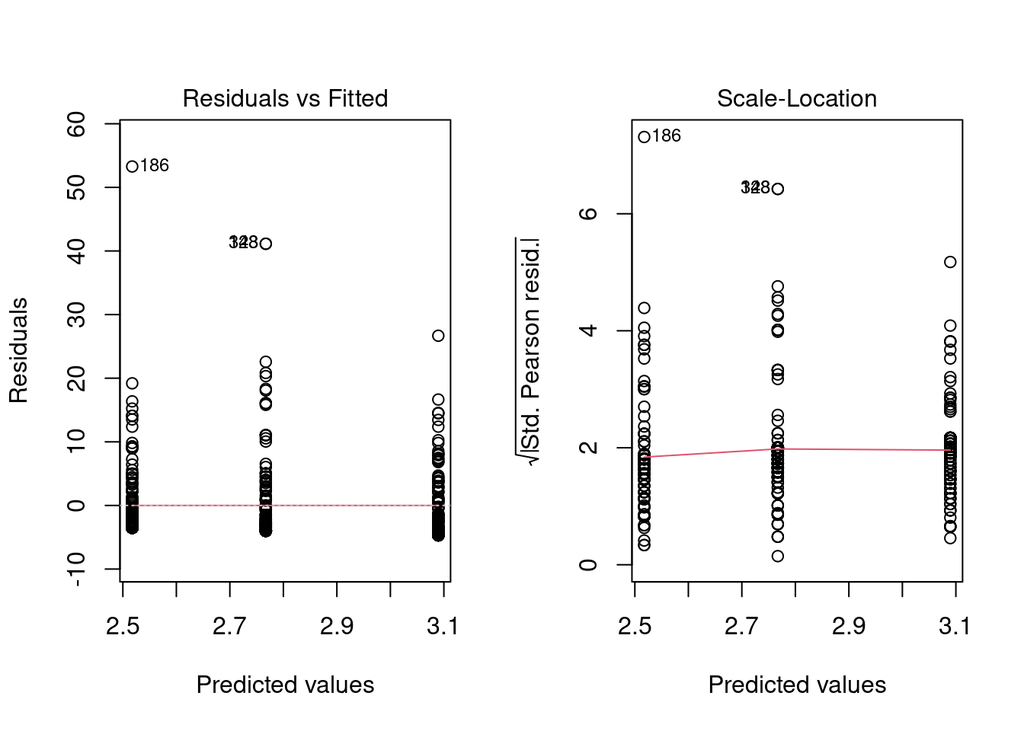

```r
par(mfrow=c(1,2))
plot(risky.glm1, which=c(1,3))
```

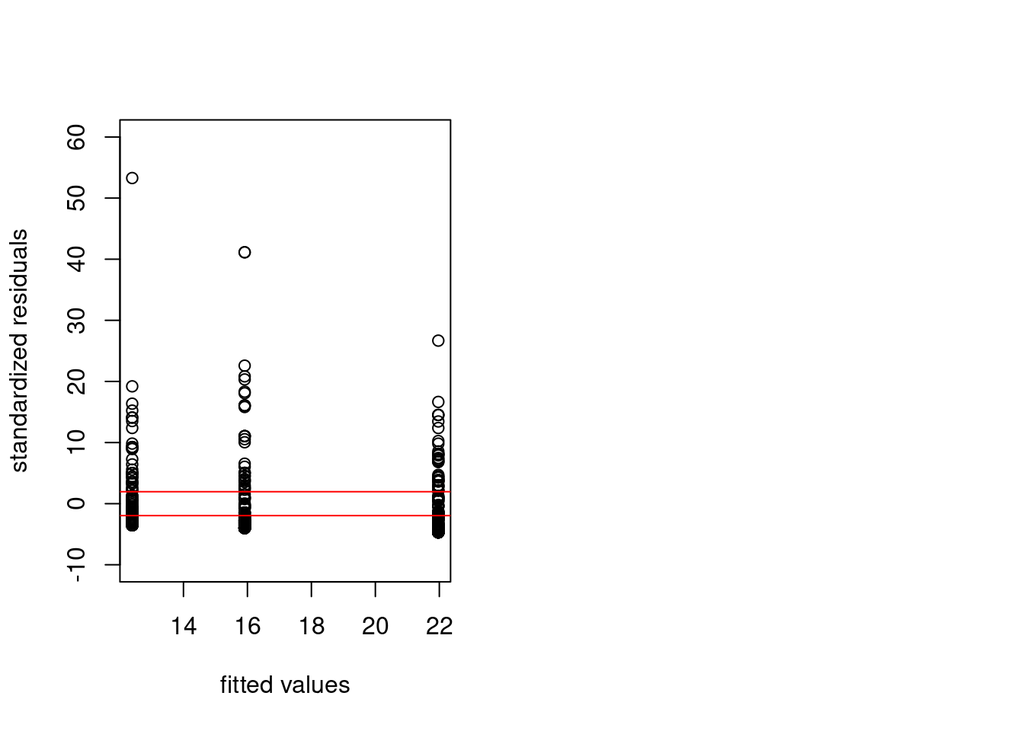

```r
#standardized residuals (the same pearson residuals in poisson)

risky.coef <- risky.glm1$coefficients
risky$mu <- risky.glm1$fitted.values
#risky$mu <- exp(risky.coef[1] + risky.coef[2]*risky$couples + risky.coef[3]*risky$women_alone+)  #inverse of link function, but first change the factors to dummy variable
risky$std.residual <- (risky$fupacts-risky$mu)/sqrt(risky$mu)
plot(risky$std.residual~risky$mu, ylab="standardized residuals", xlab="fitted values", ylim=c(-10,60))
abline(h=-1.96, col="red")
abline(h=1.96, col="red")
```

The plots of residuals show that this models doesn’t fit well and there is significant evidence of overdispersion because many residual points are out of the interval [-1.96,1.96] which is the range of standard normal distribution.

**Next extend the model to include pre-treatment measures of the outcome and the additional pre-treatment variables included in the dataset. Does the model fit well? Is there evidence of overdispersion?**

```r
#including pre-treatment variables
risky.glm2 <- glm(fupacts ~ sex+couples+women_alone+bs_hiv+bupacts, family = poisson, data=risky )
summary(risky.glm2)
```

```
##
## Call:
## glm(formula = fupacts ~ sex + couples + women_alone + bs_hiv +
##     bupacts, family = poisson, data = risky)
##
## Deviance Residuals:
##     Min       1Q   Median       3Q      Max
## -18.679   -4.305   -2.511    1.368   23.361
##
## Coefficients:
##                                     Estimate Std. Error z value Pr(>|z|)
## (Intercept)                        2.8957952  0.0232074 124.779  < 2e-16 ***
## sexman                            -0.1086694  0.0237301  -4.579 4.66e-06 ***
## couplescouple conselling          -0.4099761  0.0282298 -14.523  < 2e-16 ***
## women_aloneonly woman counselling -0.6622159  0.0308962 -21.434  < 2e-16 ***
## bs_hivpositive                    -0.4383170  0.0353804 -12.389  < 2e-16 ***
## bupacts                            0.0107789  0.0001738  62.013  < 2e-16 ***
## ---
## Signif. codes:  0 '***' 0.001 '**' 0.01 '*' 0.05 '.' 0.1 ' ' 1
##
## (Dispersion parameter for poisson family taken to be 1)
##
##     Null deviance: 13299  on 433  degrees of freedom
## Residual deviance: 10200  on 428  degrees of freedom
## AIC: 11537
##
## Number of Fisher Scoring iterations: 6
```

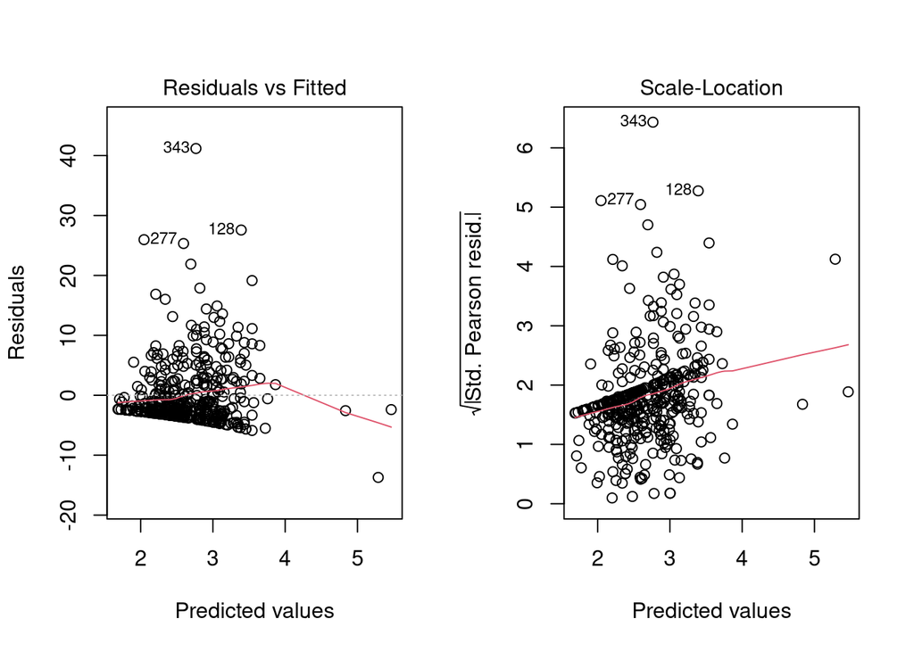

```r
par(mfrow=c(1,2))
plot(risky.glm2, which=c(1,3))
```

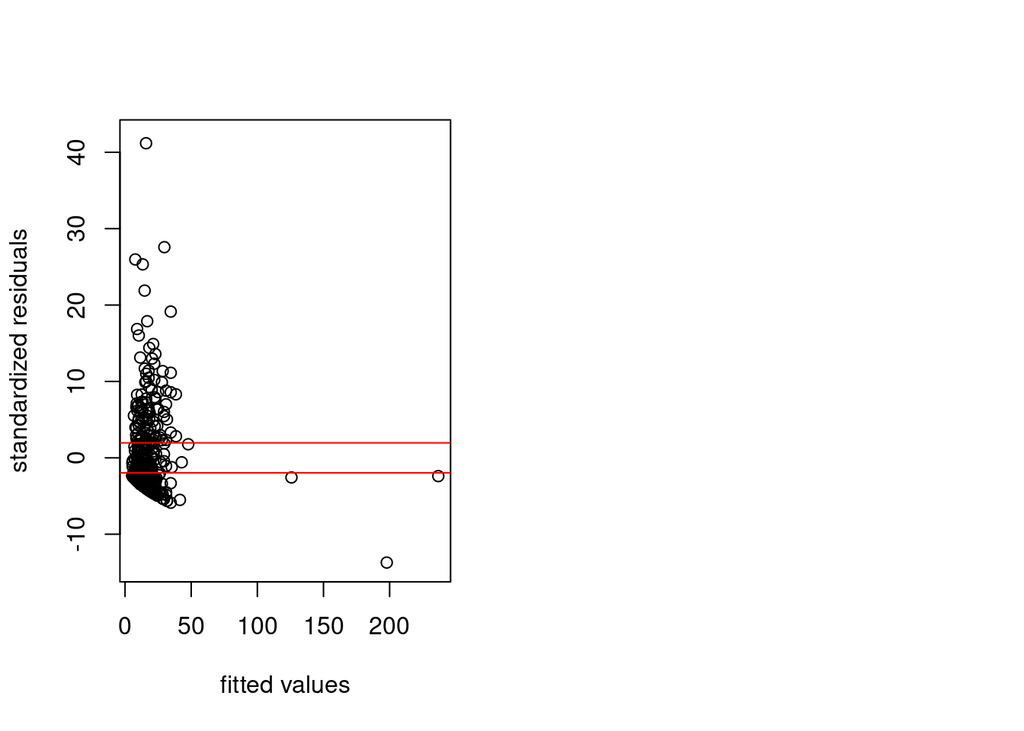

```r
#standardized residuals (the same pearson residuals in poisson)
risky.coef <- risky.glm2$coefficients
risky$mu <- risky.glm2$fitted.values
risky$std.residual <- (risky$fupacts-risky$mu)/sqrt(risky$mu)
plot(risky$std.residual~risky$mu, ylab="standardized residuals", xlab="fitted values", ylim=c(-14,42))
abline(h=-1.96, col="red")
abline(h=1.96, col="red")
```

The above residual plots show that the model doesn’t fit well and there is evidence of overdispersion.

**Fit a negative binomial (overdispersed Poisson) model. What do you conclude regarding effectiveness of the intervention?**

```r
#negative binomial model
library(MASS)
risky.nb <- glm.nb(fupacts ~ sex+couples+women_alone+bs_hiv+bupacts, data=risky, link = log)
summary(risky.nb)
```

```
##
## Call:
## glm.nb(formula = fupacts ~ sex + couples + women_alone + bs_hiv +
##     bupacts, data = risky, link = log, init.theta = 0.4169178144)
##
## Deviance Residuals:
##     Min       1Q   Median       3Q      Max
## -2.1440  -1.4856  -0.4490   0.1908   2.8009
##
## Coefficients:
##                                    Estimate Std. Error z value Pr(>|z|)
## (Intercept)                        2.436362   0.172396  14.132  < 2e-16 ***
## sexman                             0.026586   0.151850   0.175 0.861015
## couplescouple conselling          -0.350348   0.188981  -1.854 0.063757 .
## women_aloneonly woman counselling -0.717591   0.192396  -3.730 0.000192 ***
## bs_hivpositive                    -0.548626   0.186038  -2.949 0.003188 **
## bupacts                            0.022402   0.002363   9.482  < 2e-16 ***
## ---
## Signif. codes:  0 '***' 0.001 '**' 0.01 '*' 0.05 '.' 0.1 ' ' 1
##
## (Dispersion parameter for Negative Binomial(0.4169) family taken to be 1)
##
##     Null deviance: 581.87  on 433  degrees of freedom
## Residual deviance: 487.67  on 428  degrees of freedom
## AIC: 2969.7
##
## Number of Fisher Scoring iterations: 1
##
##
##               Theta:  0.4169
##           Std. Err.:  0.0313
##
##  2 x log-likelihood:  -2955.7200
```

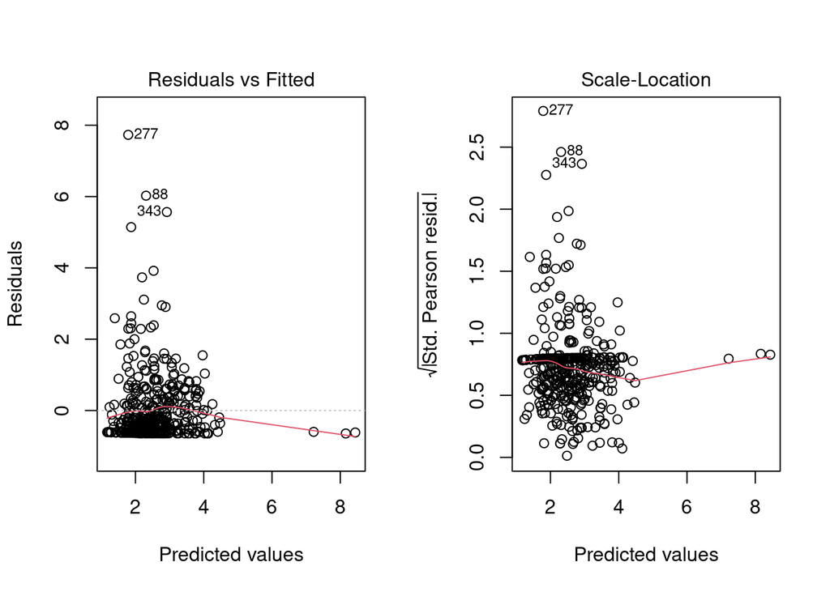

```r
par(mfrow=c(1,2))
plot(risky.nb, which=c(1,3))
```

The result of the model shows that couple counseling is not highly significant. That means counseling both members of the couple will not make a significant change in the number of their unprotected sex acts.

**These data include responses from both men and women from the participating couples. Does this give you any concern with regard to our modeling assumptions?**  
The factor “sex” is not statistically significant in the model, so it doesn’t matter which member of each couple has been interviewed.